# Ethiopia Conflict Data

Tom Brailey[^1]

10/27/2021

# 1 Introduction

This document merges information on conflict events in Ethiopia stemming from four different sources (ACLED, GTD, SCAD, UCDP GED) into one unified dataset. The dataset makes use of the MELTT algorithm developed by Donnay et al. (2019) and provides geo-referenced information on conflict events over the period 1997-2017.

The following file is organized as follows:

1. First, the separate conflict datasets are imported
2. Then, actor, event, and precision taxonomies are developed following Donnay et al. (2019)
3. Using the actor, event, and precision taxonomies the separate datasets are integrated to produce one coherent dataset using the MELTT algorithm (`meltt` package)
4. All events flagged as potential duplicates by the `meltt` package are reviewed and manually coded as unique events or duplicates
5. Finally, a unified dataset is produced.

To reproduce the final dataset, one needs the following files:

1. event_tax.csv
2. prec_tax.csv
3. actor_tax.csv
4. 1997-01-01-2022-01-31-Ethiopia.csv
5. globalterrorismdb_0221dist.csv
6. ged201.RData
7. SCAD2018Africa_Final.csv

We provide the first three dataset, but we provide written instructions for downloading the other four datasets, this is because datasets such as ACLED, though publicly available, require researchers to create an account and provide private security keys in order to download their data. Below we describe the procedure to download each of the four datasets.

The code used to reproduce the outputs can be found in the corresponding .Rmd file.

# 2 Importing datasets

```r
event_tax <- read.csv(paste0(fp_data, "event_tax.csv"))

prec_tax  <- read.csv(paste0(fp_data, "prec_tax.csv"))

actor_tax <- read.csv(paste0(fp_data, "actor_tax.csv"))
```

## 2.1 ACLED

### 2.1.1 How to Download

1. Go to https://acleddata.com/data-export-tool/.
2. Create an account.
3. Under the `Data Export Tool` heading, paste your access key, specify `From` to be “01/01/1997” and `To` to be “31/01/2022”. `Event Type`, `Sub Event Type`, `Actor Type`, `Actor`, `Region`, and `Location` should take the value of `All`. `Country` should be `Ethiopia` and `Keyword` should be left blank. Lastly, provide the email address associated with your account, and set `Export Type` to be `Actor Based`.
4. Hit `Export`.
5. Save data in a folder within your project called `ACLED`.

The ACLED dataset registers a total of 4102 observations over the period 1997-2017.

This initial cleaning of the ACLED data gives the following event types:

```r
levels(acled$event_type)
```

```
##  [1] "Battle-Government regains territory"
##  [2] "Battle-No change of territory"
##  [3] "Battle-Non-state actor overtakes territory"
##  [4] "Headquarters or base established"
##  [5] "Non-violent activity by a conflict actor"
##  [6] "Non-violent transfer of territory"
##  [7] "Protests"
##  [8] "Remote violence"
##  [9] "Riots"
## [10] "Violence against civilians"
```

We carry out further cleaning of the ACLED dataset by substituting categorical responses with numerical values and by changing the format of other variables (including latitude and longitude, and time-related variables).

```r
# looking for missing values
apply(acled, 2, function(x) any(is.na(x)))
```

```
##          data_id              iso    event_id_cnty event_id_no_cnty
##            FALSE            FALSE            FALSE            FALSE
##       event_date             year   time_precision       event_type
##            FALSE            FALSE            FALSE            FALSE
##   sub_event_type           actor1    assoc_actor_1           inter1
##            FALSE            FALSE            FALSE            FALSE
##           actor2    assoc_actor_2           inter2      interaction
##            FALSE            FALSE            FALSE            FALSE
##           region          country           admin1           admin2
##            FALSE            FALSE            FALSE            FALSE
##           admin3         location         latitude        longitude
##            FALSE            FALSE            FALSE            FALSE
##    geo_precision           source     source_scale            notes
##            FALSE            FALSE            FALSE            FALSE
##       fatalities        timestamp             iso3      event_type2
##            FALSE            FALSE            FALSE            FALSE
```

```r
# now for columns, INTER1, INTER2 and INTERACTION numerical substitutes for
# categories are provided. replace them with the actual values from the
# codebook.
# inter1

acled$inter1 <- as.character(acled$inter1)

table(acled$inter1)
```

```
##
##    1    2    3    4    5    6    8
## 1612  384  180  229  243 1429   25
```

```r
lut1 <- c("1" = "Government or mutinous force", "2" = "Rebel force",
          "3" = "Political militia", "4" = "Ethnic militia",
          "5" = "Rioters", "6" = "Protesters", "7" = "Civilians",
          "8" = "Outside/external force")

acled$inter1 <- lut1[acled$inter1]

head(acled$inter1)
```

```
## [1] "Ethnic militia"               "Government or mutinous force"
## [3] "Rioters"                      "Rioters"
## [5] "Protesters"                   "Protesters"
```

```r
# interaction
acled$interaction <- as.character(acled$interaction)
table(acled$interaction)
```

```
##
##   10   11   12   13   14   15   16   17   18   20   22   23   27   28   30   33
##    8   32 1210   83  124  126  497  455   57   21    1    8   40   11   12    4
##   34   35   36   37   38   44   45   47   48   50   55   57   60   78   80   88
##    7    2    5  136    2  159    1   40    2   58   19   37  927   16    1    1
```

```r
lut3 <- c(
  "10" = "SOLE MILITARY ACTION", "11" = "MILITARY VERSUS MILITARY",
  "12" = "MILITARY VERSUS REBELS", "13" = "MILITARY VERSUS POLITICAL MILITIA",
  "14" = "MILITARY VERSUS COMMUNAL MILITIA", "15" = "MILITARY VERSUS RIOTERS",
  "16" = "MILITARY VERSUS PROTESTERS", "17" = "MILITARY VERSUS CIVILIANS",
  "18" = "MILITARY VERSUS OTHER", "20" = "SOLE REBEL ACTION ",
  "22" = "REBELS VERSUS REBELS", "23" = "REBELS VERSUS POLITICAL MILIITA",
  "24" = "REBELS VERSUS COMMUNAL MILITIA", "25" = "REBELS VERSUS RIOTERS",
  "26" = "REBELS VERSUS PROTESTERS", "27" = "REBELS VERSUS CIVILIANS",
  "28" = "REBELS VERSUS OTHERS", "30" = "SOLE POLITICAL MILITIA ACTION",
  "33" = "POLITICAL MILITIA VERSUS POLITICAL MILITIA",
  "34" = "POLITICAL MILITIA VERSUS COMMUNAL MILITIA",
  "35" = "POLITICAL MILITIA VERSUS RIOTERS",
  "36" = "POLITICAL MILITIA VERSUS PROTESTERS",
  "37" = "POLITICAL MILITIA VERSUS CIVILIANS",
  "38" = "POLITICAL MILITIA VERSUS OTHERS",
  "40" = "SOLE COMMUNAL MILITIA ACTION",
  "44" = "COMMUNAL MILITIA VERSUS COMMUNAL MILITIA",
  "45" = "COMMUNAL MILITIA VERSUS RIOTERS",
  "46" = "COMMUNAL MILITIA VERSUS PROTESTERS",
  "47" = "COMMUNAL MILITIA VERSUS CIVILIANS",
  "48" = "COMMUNAL MILITIA VERSUS OTHER","50" = "SOLE RIOTER ACTION",
  "55" = "RIOTERS VERSUS RIOTERS", "56" = "RIOTERS VERSUS PROTESTERS",
  "57" = "RIOTERS VERSUS CIVILIANS", "58" = "RIOTERS VERSUS OTHERS",
  "60" = "SOLE PROTESTER ACTION", "66" = "PROTESTERS VERSUS PROTESTERS",
  "67" = "PROTESTERS VERSUS CIVILIANS", "68" = "PROTESTERS VERSUS OTHER",
  "70" = "SOLE CIVILIANS", "77" = "CIVILIANS VERSUS CIVILIANS",
  "78" = "OTHER ACTOR VERSUS CIVILIANS", "80" = "SOLE OTHER ACTION",
  "88" = "OTHERS VERSUS OTHERS")

acled$interaction <- lut3[acled$interaction]
head(acled$interaction)
```

```
## [1] "COMMUNAL MILITIA VERSUS COMMUNAL MILITIA"
## [2] "MILITARY VERSUS COMMUNAL MILITIA"
## [3] "SOLE RIOTER ACTION"
## [4] "RIOTERS VERSUS RIOTERS"
## [5] "SOLE PROTESTER ACTION"
## [6] "SOLE PROTESTER ACTION"
```

```r
# convert LONGITUDE and LATITUDE columns to Numeric
acled$longitude <- as.numeric(acled$longitude)
acled$latitude <- as.numeric(acled$latitude)

# convert actor1 and actor2 to factor
acled$actor1 <- as.factor(acled$actor1)
acled$actor2 <- as.factor(acled$actor2)

# the event date column is in DD/MM/YYYY format. assign this to the dataset
# using dmy() function
head(acled$event_date)
```

```
## [1] "30 December 2017" "30 December 2017" "29 December 2017" "29 December 2017"
## [5] "29 December 2017" "29 December 2017"
```

```r
acled$event_date <- lubridate::dmy(acled$event_date)
head(acled$event_date)
```

```
## [1] "2017-12-30" "2017-12-30" "2017-12-29" "2017-12-29" "2017-12-29"
## [6] "2017-12-29"
```

```r
# for further analysis and aggregating data on monthly basis, mutate the
# dataset to add a column for month
acled %<>% dplyr::mutate(month = lubridate::month(acled$event_date))

# sum by lat/long and month
acled$longlat <- paste(acled$longitude, acled$latitude, sep = ", ")

acled$ym <- zoo::as.yearmon(
  paste(acled$year, acled$month, sep = "-"), "%Y-%m")

#acled_dissag<-acled %>%
#  dplyr::group_by(longitude, latitude, ym, event_type) %>%
#  dplyr::summarise(fatalities = sum(fatalities, na.rm = TRUE))
```

We look for potential duplicate events in the data by inspecting instances where all the main variables display the same value, and drop redundant observations. This process lead us to drop 31 observations (the total number of observations in ACLED is then 4071).

```r
# inspecting duplicates
duplic <- acled[
  duplicated(
    acled[ , c(
      "event_date", "year", "time_precision", "event_type",
      "sub_event_type",  "actor1", "assoc_actor_1", "inter1", "actor2",
      "assoc_actor_2", "inter2",  "interaction", "region", "country",
      "admin1", "admin2", "admin3", "location", "latitude", "longitude",
      "geo_precision")]),]

nrow(duplic)
```

```
## [1] 31
```

```r
#duplic2 <- acled[
#  !duplicated(
#    acled[ , c("event_date", "year", "time_precision", "event_type",
#               "sub_event_type",  "actor1", "assoc_actor_1", "inter1",
#               "actor2", "assoc_actor_2", "inter2",  "interaction",
#               "region", "country", "admin1", "admin2", "admin3",
#               "location", "latitude", "longitude", "geo_precision")]),]

#compare <- setdiff(duplic2, duplic)

# deleting duplicates
acled <- acled[
  !duplicated(
    acled[ , c(
      "event_date", "year", "time_precision", "event_type",
      "sub_event_type",  "actor1", "assoc_actor_1", "inter1", "actor2",
      "assoc_actor_2", "inter2",  "interaction", "region", "country",
      "admin1", "admin2", "admin3", "location", "latitude", "longitude",
      "geo_precision")]),]
```

Moreover, the structure of the ACLED dataset is in long format, meaning that event spanning multiple days are registered as separate observations. This is in contrast with other conflict event data sources, where one event corresponds to one observation. For this reason, we try to reshape the ACLED dataset into wide format. We do this by looking for events occurring on consecutive days in the same location and involving the same actors, and transforming them into the same unique event.

After reshaping, the number of observations decreases further to 3700 observations.

```r
# reshaping from long to wide
data.table::setDT(acled)

acled[, Date := as.Date(event_date, format = '%Y/%m/%d')]

acled_old <- acled #keep old data

acled <- acled_old[
  order(longlat, event_type, actor1, actor2, year, time_precision,
        sub_event_type, assoc_actor_1, inter1, assoc_actor_2, inter2,
        interaction, region,  country, admin1,  admin2, admin3, location,
        latitude, longitude, geo_precision, fatalities, Date),
  .(start = min(Date), end = max(Date)),
          by = .(longlat, event_type, actor1, actor2, year, time_precision,
                 sub_event_type, assoc_actor_1, inter1, assoc_actor_2,
                 inter2, interaction, region,  country, admin1,  admin2,
                 admin3, location, latitude, longitude, geo_precision,
                 fatalities,
                 g = cumsum(c(0, diff(Date)) != 1))]

nrow(acled)
```

```
## [1] 3700
```

## 2.2 GTD

### 2.2.1 How to Download

1. Go to https://www.start.umd.edu/gtd/contact/download
2. Provide contact and institutional details. `Country` should be set to `Ethiopia` (you will be given all years in the GTD dataset, but you will subset these values in the code chunk below).
3. Once you have received approval, download the data and store it in a folder called “GTD”.

Subsetting the GTD dataset to years between 1997 and 2017 results in 109 observations.

```r
gtd <- read.csv(paste0(fp_data, "/GTD/globalterrorismdb_0221dist.csv"))

gtd <- subset(gtd, country_txt == "Ethiopia")
unique(gtd$iyear)
```

```
##  [1] 1970 1971 1973 1974 1975 1976 1977 1978 1979 1983 1984 1985 1986 1987 1988
## [16] 1989 1990 1991 1992 1994 1995 1996 1997 1999 2000 2002 2003 2004 2005 2006
## [31] 2007 2008 2009 2010 2011 2012 2013 2014 2015 2016 2017 2018 2019
```

```r
# Subset to 1996+ otherwise you get points outside of (current) Ethiopia
gtd <- subset(gtd, iyear >= 1997)
gtd <- subset(gtd, iyear <= 2017) # possible to extend

nrow(gtd)
```

```
## [1] 109
```

We also look for potential duplicate observations by inspecting instances where the main variables have the same value, and drop 8 duplicated events, leading to a total of 101 observations.

```r
# inspecting duplicates
duplic <- gtd[
  duplicated(
    gtd[ , c(
      "iyear", "imonth", "iday", "approxdate",  "extended", "resolution",
      "country", "country_txt", "region",  "region_txt", "provstate",
      "city", "location", "latitude", "longitude", "specificity",
      "attacktype1", "attacktype1_txt", "attacktype2", "attacktype2_txt",
      "attacktype3", "attacktype3_txt", "targtype1", "targtype1_txt",
      "targsubtype1", "targsubtype1_txt", "corp1", "target1", "natlty1",
      "natlty1_txt", "targtype2", "targtype2_txt", "targsubtype2",
      "targsubtype2_txt", "corp2", "target2", "natlty2", "natlty2_txt",
      "targtype3", "targtype3_txt", "targsubtype3", "targsubtype3_txt",
      "corp3", "target3", "natlty3", "natlty3_txt", "gname", "gsubname",
      "gname2", "gsubname2", "gname3", "gsubname3", "motive",
      "guncertain1", "guncertain2", "guncertain3", "individual", "nperps",
      "nperpcap", "claimed", "claimmode", "claimmode_txt", "claim2",
      "claimmode2", "claimmode2_txt", "claim3", "claimmode3",
      "claimmode3_txt", "compclaim", "weaptype1", "weaptype1_txt",
      "weapsubtype1", "weapsubtype1_txt", "weaptype2", "weaptype2_txt",
      "weapsubtype2", "weapsubtype2_txt", "weaptype3", "weaptype3_txt",
      "weapsubtype3", "weapsubtype3_txt", "weaptype4", "weaptype4_txt",
      "weapsubtype4", "weapsubtype4_txt", "weapdetail", "nkill", "nkillus",
      "nkillter", "nwound", "nwoundus", "nwoundte", "property",
      "propextent", "propextent_txt", "propvalue", "propcomment",
      "ishostkid", "nhostkid", "nhostkidus", "nhours", "ndays")]),]


# deleting duplicates
gtd <- gtd[
  !duplicated(
    gtd[ , c(
      "iyear", "imonth", "iday", "approxdate",  "extended", "resolution",
      "country", "country_txt", "region",  "region_txt", "provstate",
      "city", "location", "latitude", "longitude", "specificity",
      "attacktype1", "attacktype1_txt", "attacktype2", "attacktype2_txt",
      "attacktype3", "attacktype3_txt", "targtype1", "targtype1_txt",
      "targsubtype1", "targsubtype1_txt", "corp1", "target1", "natlty1",
      "natlty1_txt", "targtype2", "targtype2_txt", "targsubtype2",
      "targsubtype2_txt", "corp2", "target2", "natlty2", "natlty2_txt",
      "targtype3", "targtype3_txt", "targsubtype3", "targsubtype3_txt",
      "corp3", "target3", "natlty3", "natlty3_txt", "gname", "gsubname",
      "gname2", "gsubname2", "gname3", "gsubname3", "motive",
      "guncertain1", "guncertain2", "guncertain3", "individual", "nperps",
      "nperpcap", "claimed", "claimmode", "claimmode_txt", "claim2",
      "claimmode2", "claimmode2_txt", "claim3", "claimmode3",
      "claimmode3_txt", "compclaim", "weaptype1", "weaptype1_txt",
      "weapsubtype1", "weapsubtype1_txt", "weaptype2", "weaptype2_txt",
      "weapsubtype2", "weapsubtype2_txt", "weaptype3", "weaptype3_txt",
      "weapsubtype3", "weapsubtype3_txt", "weaptype4", "weaptype4_txt",
      "weapsubtype4", "weapsubtype4_txt", "weapdetail", "nkill", "nkillus",
      "nkillter", "nwound", "nwoundus", "nwoundte", "property",
      "propextent", "propextent_txt", "propvalue", "propcomment",
      "ishostkid", "nhostkid", "nhostkidus", "nhours", "ndays")]),]

duplic$eventid
```

```
## [1] 199704120009 201604150018 201604150019 201604150021 201604150022
## [6] 201604150023 201604150024
```

```r
# another event that is actually a duplicate, but has been inserted twice
# with slightly different coding:
gtd <- gtd[!(gtd$eventid == 199702100009),]
```

To allow for the merging process with `meltt`, we also drop entries where geo-tagged or date information is missing or incomplete, leading to 99 observations.

```r
# convert dates to class date. rename variables to match taxonomy names.
# drop entries missing date information. drop entries missing geo-tagged
# information.
gtd %<>%
  dplyr::mutate(date = as.Date(paste0(iyear, "-", imonth, "-", iday))) %>%
  dplyr::filter(!is.na(date)) %>%
  dplyr::filter(!is.na(longitude)) %>%
  as.data.frame(.)

nrow(gtd)
```

```
## [1] 99
```

```r
# remove intermediaries
rm(duplic)
```

## 2.3 GED

### 2.3.1 How to Download

1. Go to https://ucdp.uu.se/downloads/.
2. Scroll down to `UCDP Georeferenced Event Dataset (GED) Global version`.
3. Click on the `R` tab.
4. Save the data in a folder called `UCDP GED/ged201-RData`.

Subsetting the GED dataset to years between 1997 and 2017 produces 1659 observations.

```r
load(paste0(fp_data, "/UCDP GED/ged201-RData/ged201.RData"))
ged <- subset(ged201, country == "Ethiopia")
unique(ged$year)
```

```
##  [1] 1989 1990 1991 1993 1994 1996 1999 1995 1998 2000 2001 2002 2003 2004 2005
## [16] 2006 2007 2008 2009 2010 2011 2012 2013 2014 2015 2016 2017 2018 1992 1997
## [31] 2019
```

```r
# Subset to 1996+ otherwise you get points outside of (current) Ethiopia
ged <- subset(ged, year >= 1997)
ged <- subset(ged, year <= 2017) # possible to extend
```

Again, we look for potential duplicated events by analyzing observations that display the same value for the main variables, and drop 1 duplicated event, for a total of 1658 observations.

```r
# inspecting duplicates
duplic <- ged[
  duplicated(
    ged[ , c(
      "year", "active_year", "code_status", "type_of_violence",
      "conflict_dset_id", "conflict_new_id", "conflict_name",
      "dyad_dset_id", "dyad_new_id", "dyad_name", "side_a_dset_id",
      "side_a_new_id", "side_a", "side_b_dset_id", "side_b_new_id",
      "side_b", "number_of_sources", "source_article", "source_office",
      "source_date", "source_headline", "source_original", "where_prec",
      "where_coordinates", "where_description",  "adm_1", "adm_2",
      "latitude", "longitude", "geom_wkt", "priogrid_gid", "country",
      "country_id", "region", "event_clarity", "date_prec", "date_start",
      "date_end", "deaths_a", "deaths_b", "deaths_civilians",
      "deaths_unknown", "best", "high", "low", "gwnoa", "gwnob")]),]

# deleting duplicates
# inspecting duplicates
ged <- ged[
  !duplicated(
    ged[ , c(
      "year", "active_year", "code_status", "type_of_violence",
      "conflict_dset_id", "conflict_new_id", "conflict_name",
      "dyad_dset_id", "dyad_new_id", "dyad_name", "side_a_dset_id",
      "side_a_new_id", "side_a", "side_b_dset_id", "side_b_new_id",
      "side_b", "number_of_sources", "source_article", "source_office",
      "source_date", "source_headline", "source_original", "where_prec",
      "where_coordinates", "where_description",  "adm_1", "adm_2",
      "latitude", "longitude", "geom_wkt", "priogrid_gid", "country",
      "country_id", "region", "event_clarity", "date_prec", "date_start",
      "date_end", "deaths_a", "deaths_b", "deaths_civilians",
      "deaths_unknown", "best", "high", "low", "gwnoa", "gwnob")]),]
```

Following Donnay et al. (2019) (Appendix, p.24), we swap the primary actor (side_a) and the secondary actor (side_b) for all events coded as state-based violence (type of violence = 1).

```r
# following Donnay et al. 2019 Appendix, p.24, change side_a in side_b for
# type of violence = 1
unique(paste(ged$side_a[ged$type_of_violence == 1],
             ged$side_b[ged$type_of_violence == 1], sep = ", "))
```

```
## [1] "Government of Ethiopia, AIAI"
## [2] "Government of Ethiopia, ONLF"
## [3] "Government of Somalia, Al-Shabaab"
## [4] "Government of Eritrea, Government of Ethiopia"
## [5] "Government of Ethiopia, OLF"
## [6] "Government of Sudan, SPLM/A-North"
```

```r
unique(ged$side_a[ged$type_of_violence == 1])
```

```
## [1] "Government of Ethiopia" "Government of Somalia"  "Government of Eritrea"
## [4] "Government of Sudan"
```

```r
unique(ged$side_b[ged$type_of_violence == 1])
```

```
## [1] "AIAI"                   "ONLF"                   "Al-Shabaab"
## [4] "Government of Ethiopia" "OLF"                    "SPLM/A-North"
```

```r
ged$side_a[ged$type_of_violence == 1] <-
  ged$side_b[ged$type_of_violence == 1]
```

## 2.4 SCAD

Subsetting the SCAD dataset to years between 1997 and 2017 results in 175 observations.

```r
scad <- fread(
  paste0(fp_data,
         "SCAD/SCAD2018Africa_Final.csv/SCAD2018Africa_Final.csv"))

scad <- subset(scad, countryname == "Ethiopia")

unique(scad$styr)
```

```
##  [1] 1964 1976 1987 1989 1990 1991 1992 1993 1994 1995 1996 1997 1998 1999 2000
## [16] 2001 2002 2004 2005 2006 2007 2008 2010 2011 2012 2013 2014 2015 2016 2017
```

```r
# Subset to 1996+ otherwise you get points outside of (current) Ethiopia
scad <- subset(scad, styr >= 1997)
scad <- subset(scad, eyr <= 2017)
```

As for the previous datasets, we look for potential instances of duplicated events, but do not find any in the SCAD data.

```r
# inspecting duplicates
duplic <- scad[duplicated(scad[ , c("ccode" , "countryname",
"startdate"   , "enddate"   , "duration"    , "stday"      ,
"stmo"        , "styr"      , "eday"        , "emo"        ,
"eyr"         , "etype"     , "escalation"  , "actor1"     ,
"actor2"      , "actor3"    , "target1"     , "target2"    ,
"cgovtarget"  , "rgovtarget", "npart"       , "ndeath"     ,
"repress"     , "elocal"    , "ilocal"      , "sublocal"   ,
"locnum"      , "gislocnum" , "issue1"      , "issue2"     ,
"issue3"      , "female_event", "lgtbq_issue",  "acd_questionable",
"latitude"    , "longitude" , "geo_comments", "location_precision")]),]

# deleting duplicates
scad <- scad[!duplicated(scad[ , c("ccode" , "countryname",
"startdate"   , "enddate"   , "duration"    , "stday"      ,
"stmo"        , "styr"      , "eday"        , "emo"        ,
"eyr"         , "etype"     , "escalation"  , "actor1"     ,
"actor2"      , "actor3"    , "target1"     , "target2"    ,
"cgovtarget"  , "rgovtarget", "npart"       , "ndeath"     ,
"repress"     , "elocal"    , "ilocal"      , "sublocal"   ,
"locnum"      , "gislocnum" , "issue1"      , "issue2"     ,
"issue3"      , "female_event", "lgtbq_issue",  "acd_questionable",
"latitude"    , "longitude" , "geo_comments", "location_precision")]),]
```

```r
# remove intermediaries
rm(duplic)
```

# 3 Developing taxonomies

## 3.1 Actor taxonomy

We develop the actor taxonomies separately for each conflict dataset. The initial recoding process relies on existing research, existing databases, and online resources. We then use the taxonomy developed by Donnay et al. (2019) to standardise actors across datasets. This can be found in the file `summary.rmd` and on our OSF page.

### 3.1.1 ACLED

```r
####ACLED####
# Create dataframe with data.source and base.categories
base.categories <- levels(acled$actor1)
data.source <- rep("acled", length(base.categories))
acled_actor_tax <- as.data.frame(cbind(data.source, base.categories))

head(acled_actor_tax)
```

```
##   data.source                                             base.categories
## 1       acled                        Ablek Ad'ali Clan Militia (Ethiopia)
## 2       acled                      ADFM: Amhara Democratic Force Movement
## 3       acled                              Afar Ethnic Militia (Ethiopia)
## 4       acled AGUDM: Patriotic Ginbot 7 for Unity and Democratic Movement
## 5       acled                                  AIAI: Al-Itihad Al-Islamia
## 6       acled                                                  Al Shabaab
```

```r
# Need to create variable actor_level_1_txt starting from base.categories
# government, violent groups, civilian groups, civilians, movement groups
# there is not civilian groups here
acled_actor_tax$actor_level_1_txt[
  grepl("Government", acled_actor_tax$base.categories)] <- "government"

acled_actor_tax$actor_level_1_txt[
  grepl("Military", acled_actor_tax$base.categories)] <- "government"

acled_actor_tax$actor_level_1_txt[
  grepl("Police", acled_actor_tax$base.categories)] <- "government"

acled_actor_tax$actor_level_1_txt[
  grepl("Militia", acled_actor_tax$base.categories)] <- "violent groups"

acled_actor_tax$actor_level_1_txt[
  grepl("Rioters", acled_actor_tax$base.categories)] <- "violent groups"

acled_actor_tax$actor_level_1_txt[
  grepl("Armed Group", acled_actor_tax$base.categories)] <- "violent groups"

acled_actor_tax$actor_level_1_txt[
  grepl("Civilians", acled_actor_tax$base.categories)] <- "civilians"

acled_actor_tax$actor_level_1_txt[
  grepl("Protesters", acled_actor_tax$base.categories)] <- "movement groups"

acled_actor_tax$actor_level_1_txt[
  grepl("Party", acled_actor_tax$base.categories)] <- "movement groups"

acled_actor_tax$actor_level_1_txt[
  grepl("Movement", acled_actor_tax$base.categories)] <- "movement groups"

# A few have not been categorised, so do it manually
acled_actor_tax$base.categories[
  is.na(acled_actor_tax$actor_level_1_txt)]
```

```
##  [1] "AIAI: Al-Itihad Al-Islamia"
##  [2] "Al Shabaab"
##  [3] "Amhara Tegadlo"
##  [4] "ARDUF: Afar Revolutionary Democratic Unity Front"
##  [5] "EPPF: Ethiopian Peoples Patriotic Front"
##  [6] "EPRDF: Ethiopian People's Revolutionary Democratic Front"
##  [7] "EUFF: Ethiopian Unity and Freedom Force"
##  [8] "MEDREK: Ethiopian Federal Democratic Unity Forum"
##  [9] "OLF: Oromo Liberation Front"
## [10] "ONLF: Ogaden National Liberation Front"
## [11] "RRA: Rahanweyn Resistance Army"
## [12] "RSADO: Red Sea Afar Democratic Organisation"
## [13] "TPLF: Tigray People's Liberation Front"
## [14] "UWSLF: United Western Somali Liberation Front"
```

```r
acled_actor_tax$actor_level_1_txt[
  acled_actor_tax$base.categories == "AIAI: Al-Itihad Al-Islamia"] <-
  "violent groups"

acled_actor_tax$actor_level_1_txt[
  acled_actor_tax$base.categories == "Al-Shabiba Al-Islamiyah"] <-
  "violent groups"

acled_actor_tax$actor_level_1_txt[
  acled_actor_tax$base.categories == "Al Shabaab"] <-
  "violent groups"

acled_actor_tax$actor_level_1_txt[
  acled_actor_tax$base.categories == "Amhara Tegadlo"] <-
  "movement groups"

# These are more difficult to categorise
acled_actor_tax$base.categories[
  is.na(acled_actor_tax$actor_level_1_txt)]
```

```
##  [1] "ARDUF: Afar Revolutionary Democratic Unity Front"
##  [2] "EPPF: Ethiopian Peoples Patriotic Front"
##  [3] "EPRDF: Ethiopian People's Revolutionary Democratic Front"
##  [4] "EUFF: Ethiopian Unity and Freedom Force"
##  [5] "MEDREK: Ethiopian Federal Democratic Unity Forum"
##  [6] "OLF: Oromo Liberation Front"
##  [7] "ONLF: Ogaden National Liberation Front"
##  [8] "RRA: Rahanweyn Resistance Army"
##  [9] "RSADO: Red Sea Afar Democratic Organisation"
## [10] "TPLF: Tigray People's Liberation Front"
## [11] "UWSLF: United Western Somali Liberation Front"
```

```r
acled_actor_tax$actor_level_1_txt[
  acled_actor_tax$base.categories ==
    "ARDUF: Afar Revolutionary Democratic Unity Front"] <- "movement groups"

acled_actor_tax$actor_level_1_txt[
  acled_actor_tax$base.categories ==
    "EDU: Front of the Ethiopian Democratic Union Forces"] <- "movement groups"

acled_actor_tax$actor_level_1_txt[
  acled_actor_tax$base.categories ==
    "EPPF: Ethiopian Peoples Patriotic Front"] <- "violent groups"

acled_actor_tax$actor_level_1_txt[
  acled_actor_tax$base.categories ==
    "EPRDF: Ethiopian Peoples Revolutionary Democratic Front"] <-
  "movement groups"

acled_actor_tax$actor_level_1_txt[
  acled_actor_tax$base.categories ==
    "EPRDF: Ethiopian People's Revolutionary Democratic Front"] <-
  "movement groups"

acled_actor_tax$actor_level_1_txt[
  acled_actor_tax$base.categories ==
    "EUFF: Ethiopian Unity and Freedom Force"] <- "violent groups"

acled_actor_tax$actor_level_1_txt[
  acled_actor_tax$base.categories ==
    "MEDREK: Ethiopian Federal Democratic Unity Forum"] <- "movement groups"

acled_actor_tax$actor_level_1_txt[
  acled_actor_tax$base.categories ==
    "OLF: Oromo Liberation Front"] <- "movement groups"

acled_actor_tax$actor_level_1_txt[
  acled_actor_tax$base.categories ==
    "ONLF: Ogaden National Liberation Front"] <- "movement groups"

acled_actor_tax$actor_level_1_txt[
  acled_actor_tax$base.categories ==
    "OPDO: Oromo Peoples Democratic Organization"] <- "movement groups"

acled_actor_tax$actor_level_1_txt[
  acled_actor_tax$base.categories ==
    "RRA: Rahanweyn Resistance Army"] <- "violent groups"

acled_actor_tax$actor_level_1_txt[
  acled_actor_tax$base.categories ==
    "RSADO: Red Sea Afar Democratic Organisation"] <- "movement groups"

acled_actor_tax$actor_level_1_txt[
  acled_actor_tax$base.categories ==
    "SLF: Sidama Liberation Front"] <- "violent groups"

acled_actor_tax$actor_level_1_txt[
  acled_actor_tax$base.categories ==
    "TPLF: Tigray Peoples Liberation Front"] <- "movement groups"

acled_actor_tax$actor_level_1_txt[
  acled_actor_tax$base.categories ==
    "TPLF: Tigray People's Liberation Front"] <- "movement groups"

acled_actor_tax$actor_level_1_txt[
  acled_actor_tax$base.categories ==
    "UWSLF: United Western Somali Liberation Front"] <- "violent groups"

acled_actor_tax$base.categories[
  is.na(acled_actor_tax$actor_level_1_txt)]
```

```
## character(0)
```

```r
# Need to create variable actor_level_2_txt starting from actor_level_1_txt
# government and violent groups are violent groups, the others are nonviolent
# groups
acled_actor_tax$actor_level_2_txt <- "nonviolent groups"

acled_actor_tax$actor_level_2_txt[
  acled_actor_tax$actor_level_1_txt == "government" |
    acled_actor_tax$actor_level_1_txt == "violent groups"] <- "violent groups"
```

```r
# checking that ACLED's actor taxonomy cover all actors
acled_actor <- acled %>%
  dplyr::left_join(
    acled_actor_tax, by = c("actor1" = "base.categories")) %>%
  dplyr::select(actor1, actor2, actor_level_1_txt, actor_level_2_txt)

# looking for missing values (all outputs should be FALSE)
apply(acled_actor, 2, function(x) any(is.na(x)))
```

```
##            actor1            actor2 actor_level_1_txt actor_level_2_txt
##             FALSE             FALSE             FALSE             FALSE
```

### 3.1.2 GED

```r
####GED####
# Create dataframe with data.source and base.categories
base.categories <- unique(ged$side_a)
data.source <- rep("ged", length(base.categories))
ged_actor_tax <- as.data.frame(cbind(data.source,base.categories))

head(ged_actor_tax)
```

```
##   data.source        base.categories
## 1         ged                   AIAI
## 2         ged                   ONLF
## 3         ged             Al-Shabaab
## 4         ged Government of Ethiopia
## 5         ged                    OLF
## 6         ged    Government of Kenya
```

```r
# Need to create variable actor_level_1_txt starting from base.categories
# all non-state are violent groups, otherwise government
ged_actor_tax$actor_level_1_txt <- "violent groups"

ged_actor_tax$actor_level_1_txt[
  grepl("Government", ged_actor_tax$base.categories)] <- "government"

# Need to create variable actor_level_2_txt starting from actor_level_1_txt
# all are violent groups Donnay et al. Appendix p.22
ged_actor_tax$actor_level_2_txt <- "violent groups"

# checking that GED's actor taxonomy covers all actors
ged_actor <- ged %>%
  dplyr::left_join(ged_actor_tax, by = c("side_a" = "base.categories")) %>%
  dplyr::select(side_a, side_b, actor_level_1_txt, actor_level_2_txt)

# looking for missing values
apply(ged_actor, 2, function(x) any(is.na(x)))
```

```
##            side_a            side_b actor_level_1_txt actor_level_2_txt
##             FALSE             FALSE             FALSE             FALSE
```

### 3.1.3 SCAD

```r
####SCAD####
# Create dataframe with data.source and base.categories
base.categories <- unique(as.character(scad$actor1))
data.source <- rep("scad", length(base.categories))
scad_actor_tax <- as.data.frame(cbind(data.source,base.categories))

# Need to create variable actor_level_1_txt starting from base.categories
# government, violent groups, civilian groups, civilians, movement groups,
# religious groups
scad_actor_tax$actor_level_1_txt[
  scad_actor_tax$base.categories=="students"] <- "civilians"
scad_actor_tax$actor_level_1_txt[
  scad_actor_tax$base.categories=="Ethiopians"] <- "civilians"
scad_actor_tax$actor_level_1_txt[
  scad_actor_tax$base.categories=="taxi drivers"] <- "civilian groups"
scad_actor_tax$actor_level_1_txt[
  scad_actor_tax$base.categories=="demonstrators"] <- "movement groups"
scad_actor_tax$actor_level_1_txt[
  scad_actor_tax$base.categories==
    "Demonstrators angry over the deaths Irreecha festival attendees"] <-
  "movement groups"
scad_actor_tax$actor_level_1_txt[
  scad_actor_tax$base.categories=="Armed men"] <- "violent groups"
scad_actor_tax$actor_level_1_txt[
  scad_actor_tax$base.categories=="voters"] <- "civilians"
scad_actor_tax$actor_level_1_txt[
  scad_actor_tax$base.categories=="journalists"] <- "civilian groups"
scad_actor_tax$actor_level_1_txt[
  scad_actor_tax$base.categories=="women"] <- "civilians"
scad_actor_tax$actor_level_1_txt[
  scad_actor_tax$base.categories=="Bandits"] <- "violent groups"
scad_actor_tax$actor_level_1_txt[
  scad_actor_tax$base.categories=="attackers"] <- "violent groups"
scad_actor_tax$actor_level_1_txt[
  scad_actor_tax$base.categories=="OLF"] <- "movement groups"
scad_actor_tax$actor_level_1_txt[
  scad_actor_tax$base.categories=="ONLF"] <- "movement groups"
scad_actor_tax$actor_level_1_txt[
  scad_actor_tax$base.categories=="al-Itahad al-Islami"] <- "violent groups"
scad_actor_tax$actor_level_1_txt[
  scad_actor_tax$base.categories=="Al-Itihad Al-Islamiya"] <- "violent groups"
scad_actor_tax$actor_level_1_txt[
  grepl("opposition",scad_actor_tax$base.categories)] <- "movement groups"
scad_actor_tax$actor_level_1_txt[
  grepl("tribe",tolower(scad_actor_tax$base.categories))] <- "civilian groups"
scad_actor_tax$actor_level_1_txt[
  scad_actor_tax$base.categories=="Oromo ethnic group"] <- "civilian groups"
scad_actor_tax$actor_level_1_txt[
  scad_actor_tax$base.categories==
    "Ethiopian People's Revolutionary Democratic Front"] <- "movement groups"
scad_actor_tax$actor_level_1_txt[
  scad_actor_tax$base.categories==
    "pro-government supporters"] <- "movement groups"
scad_actor_tax$actor_level_1_txt[
  grepl(
    "protesters",
    tolower(scad_actor_tax$base.categories))] <- "movement groups"
scad_actor_tax$actor_level_1_txt[
  scad_actor_tax$base.categories=="Gunmen"] <- "violent groups"
scad_actor_tax$actor_level_1_txt[
  grepl("clan",scad_actor_tax$base.categories)] <- "violent groups"
scad_actor_tax$actor_level_1_txt[
  scad_actor_tax$base.categories=="Islamic youth"] <- "religious groups"
scad_actor_tax$actor_level_1_txt[
  scad_actor_tax$base.categories=="market traders"] <- "civilian groups"
scad_actor_tax$actor_level_1_txt[
  scad_actor_tax$base.categories=="Christians"] <- "religious groups"
scad_actor_tax$actor_level_1_txt[
  scad_actor_tax$base.categories=="Muslims"] <- "religious groups"
scad_actor_tax$actor_level_1_txt[
  scad_actor_tax$base.categories=="truckers"] <- "civilian groups"
scad_actor_tax$actor_level_1_txt[
  scad_actor_tax$base.categories=="Shopkeepers"] <- "civilian groups"
scad_actor_tax$actor_level_1_txt[
  scad_actor_tax$base.categories=="Soldiers"] <- "government"
scad_actor_tax$actor_level_1_txt[
  scad_actor_tax$base.categories=="Security forces"] <- "government"
scad_actor_tax$actor_level_1_txt[
  scad_actor_tax$base.categories=="Suspected security forces"] <- "government"
scad_actor_tax$actor_level_1_txt[
  grepl("Police",scad_actor_tax$base.categories)] <- "government"
scad_actor_tax$actor_level_1_txt[
  grepl("gunmen",scad_actor_tax$base.categories)] <- "violent groups"
scad_actor_tax$actor_level_1_txt[
  scad_actor_tax$base.categories=="Anuak militants"] <- "violent groups"
scad_actor_tax$actor_level_1_txt[
  grepl("bombers",scad_actor_tax$base.categories)] <- "violent groups"
scad_actor_tax$actor_level_1_txt[
  scad_actor_tax$base.categories=="Attackers"] <- "violent groups"
scad_actor_tax$actor_level_1_txt[
  scad_actor_tax$base.categories=="Rebels"] <- "violent groups"
scad_actor_tax$actor_level_1_txt[
  scad_actor_tax$base.categories=="Eritrean Refugees"] <- "civilians"
scad_actor_tax$actor_level_1_txt[
  scad_actor_tax$base.categories=="South Sudanese refugees"] <- "civilians"
scad_actor_tax$actor_level_1_txt[
  scad_actor_tax$base.categories==
    "Participants in Irreecha religious festival"] <- "civilians"
scad_actor_tax$actor_level_1_txt[
  grepl("Students",scad_actor_tax$base.categories)] <- "civilians"
scad_actor_tax$actor_level_1_txt[
  scad_actor_tax$base.categories=="Athletes"] <- "civilian groups"
scad_actor_tax$actor_level_1_txt[
  scad_actor_tax$base.categories==
    "Bashir Isaac Abdulla, demonstration organizer"] <- "movement groups"
scad_actor_tax$actor_level_1_txt[
  scad_actor_tax$base.categories==
    "Coalition for Unity and Democracy"] <- "movement groups"
scad_actor_tax$actor_level_1_txt[
  scad_actor_tax$base.categories==
    "Government-sponsored march"] <- "movement groups"
scad_actor_tax$actor_level_1_txt[
  grepl("Ethnic",scad_actor_tax$base.categories)] <- "civilians"
scad_actor_tax$actor_level_1_txt[
  scad_actor_tax$base.categories=="Eritrean exiles"] <- "civilians"
scad_actor_tax$actor_level_1_txt[
  scad_actor_tax$base.categories=="Unknown attackers"] <- "violent groups"
scad_actor_tax$actor_level_1_txt[
  scad_actor_tax$base.categories==
    "Ogaden National Liberation Front"] <- "movement groups"

# these categories are new:
scad_actor_tax$actor_level_1_txt[
  scad_actor_tax$base.categories=="Cattle Herders"] <- "violent groups"
scad_actor_tax$actor_level_1_txt[
  scad_actor_tax$base.categories=="Somali mob"] <- "violent groups"
scad_actor_tax$actor_level_1_txt[
  scad_actor_tax$base.categories=="Oromo rioters"] <- "violent groups"
scad_actor_tax$actor_level_1_txt[
  scad_actor_tax$base.categories=="Somali rioters"] <- "violent groups"
scad_actor_tax$actor_level_1_txt[
  scad_actor_tax$base.categories=="Somali Rioters"] <- "violent groups"
scad_actor_tax$actor_level_1_txt[
  scad_actor_tax$base.categories=="Security Forces"] <- "government"
scad_actor_tax$actor_level_1_txt[
  scad_actor_tax$base.categories=="Ethiopian government"] <- "government"

# looking into the unknowns:
scad_actor_tax$actor_level_1_txt[
  scad_actor_tax$base.categories=="Unknown attackers"] <- "violent groups"
scad_actor_tax$actor_level_1_txt[
  scad_actor_tax$base.categories=="Unknown armed men"] <- "violent groups"
scad_actor_tax$actor_level_1_txt[
  scad_actor_tax$base.categories=="Unknown Bombers"] <- "violent groups"
scad_actor_tax$actor_level_1_txt[
  scad_actor_tax$base.categories=="Unidentified assailants"] <- "violent groups"
```

```r
# checking that SCAD's actor taxonomy covers all actors
scad_actor <- scad %>%
  dplyr::left_join(
    scad_actor_tax, by = c("actor1" = "base.categories")) %>%
  dplyr::mutate(base.categories = actor1)

# looking for missing values
apply(scad_actor_tax, 2, function(x) any(is.na(x)))
```

```
##       data.source   base.categories actor_level_1_txt
##             FALSE             FALSE              TRUE
```

```r
# There are further "unknowns" that need to be coded manually: to do so, we
# merge again with the original SCD data, and look  more precisely in the notes
# for clues about the unknown actors
scad_actor$actor_level_1_txt[
  scad_actor$actor1=="Unknown" &
    grepl("Gunmen",scad_actor$issuenote)] <- "violent groups"
# in this case, we see that while the actor is unknown, there are "gunmen"
# driving an attack in the notes
scad_actor$base.categories[
  scad_actor$actor1=="Unknown" &
    grepl("Gunmen",scad_actor$issuenote)] <- "Unknown gunmen"
# we also edit the base.categories variable, as it will later be necessary to
# reconstruct the actor taxonomy
scad$actor1[
  scad$actor1=="Unknown" & grepl("Gunmen",scad$issuenote)] <- "Unknown gunmen"
# we also edit the original scad dataset to mirror these changes

scad_actor$actor_level_1_txt[
  scad_actor$actor1=="unknown" &
    grepl("Violent clashes", scad_actor$issuenote)] <- "violent groups"
# in this case, we see that while the actor is unknown, "violent clashes" are
# described in the notes

scad_actor$base.categories[
  scad_actor$actor1=="unknown" &
    grepl("Violent clashes", scad_actor$issuenote)] <- "Unknown violent clashes"
# we also edit the base.categories variable, as it will later be necessary to
# reconstruct the actor taxonomy

scad$actor1[
  scad$actor1=="unknown" &
    grepl("Violent clashes",scad$issuenote)] <- "Unknown violent clashes"
# we also edit the original scad dataset to mirror these changes

scad_actor$actor_level_1_txt[
  scad_actor$actor1=="Unknown" &
    grepl("grenade",scad_actor$issuenote)] <- "violent groups"
# in this case, we see that while the actor is unknown, a grenade attack is
# described in the notes

scad_actor$base.categories[
  scad_actor$actor1=="Unknown" &
    grepl("grenade",scad_actor$issuenote)] <- "Unknown attack"
# we also edit the base.categories variable, as it will later be necessary to
# reconstruct the actor taxonomy

scad$actor1[
  scad$actor1=="Unknown" &
    grepl("grenade",scad$issuenote)] <- "Unknown attack"
# we also edit the original scad dataset to mirror these changes

scad_actor$actor_level_1_txt[
  scad_actor$actor1=="unknown" &
    grepl("grenade",scad_actor$issuenote)] <- "violent groups"
# in this case, we see that while the actor is unknown, a grenade attack is
# described in the notes

scad_actor$base.categories[
  scad_actor$actor1=="unknown" &
    grepl("grenade",scad_actor$issuenote)] <- "Unknown attack"
# we also edit the base.categories variable, as it will later be necessary to
# reconstruct the actor taxonomy

scad$actor1[
  scad$actor1=="unknown" & grepl("grenade",scad$issuenote)] <- "Unknown attack"
# we also edit the original scad dataset to mirror these changes

# Now we reconstruct SCAD's actor taxonomy:
scad_actor_tax_old <- scad_actor_tax #saving the old one for checks

scad_actor_tax <- scad_actor %>% #creating the new one from scad_actor
  dplyr::select(data.source, base.categories, actor_level_1_txt)

scad_actor_tax <- scad_actor_tax[!duplicated(scad_actor_tax$base.categories),]
# keeping only unique cases of base.categories, i.e., getting the real actor
# taxonomy

# Need to create variable actor_level_2_txt starting from actor_level_1_txt
# government and violent groups are violent groups, the others are nonviolent
# groups
scad_actor_tax$actor_level_2_txt <- "nonviolent groups"
scad_actor_tax$actor_level_2_txt[
  scad_actor_tax$actor_level_1_txt=="government"|
    scad_actor_tax$actor_level_1_txt=="violent groups"] <- "violent groups"

# recheck for missing values
apply(scad_actor_tax, 2, function(x) any(is.na(x)))
```

```
##       data.source   base.categories actor_level_1_txt actor_level_2_txt
##             FALSE             FALSE             FALSE             FALSE
```

### 3.1.4 GTD

```r
####GTD####
# Create dataframe with data.source and base.categories
base.categories<-unique(as.character(gtd$gname))
data.source<-rep("gtd",length(base.categories))
gtd_actor_tax <- as.data.frame(cbind(data.source,base.categories))


# Need to create variable actor_level_1_txt starting from base.categories
# Donnay et al. Appendix p.22: level 1 and level 2 violent groups
# So do not care about lines 146-165
gtd_actor_tax$actor_level_1_txt <- "violent groups"
gtd_actor_tax$actor_level_2_txt <- "violent groups"

# checking that GTD's actor taxonomy covers all actors
gtd_actor <- gtd %>%
  dplyr::left_join(gtd_actor_tax, by = c("gname" = "base.categories")) %>%
  dplyr::select(gname, gname2, gname3, actor_level_1_txt, actor_level_2_txt)

# looking for missing values
apply(gtd_actor, 2, function(x) any(is.na(x)))
```

```
##             gname            gname2            gname3 actor_level_1_txt
##             FALSE             FALSE             FALSE             FALSE
## actor_level_2_txt
##             FALSE
```

```r
####MERGE DIFFERENT ACTOR TAXONOMIES####
my_actor_tax <- rbind(
  acled_actor_tax,
  ged_actor_tax,
  scad_actor_tax,
  gtd_actor_tax)

# looking for missing values
apply(my_actor_tax, 2, function(x) any(is.na(x)))
```

```
##       data.source   base.categories actor_level_1_txt actor_level_2_txt
##             FALSE             FALSE             FALSE             FALSE
```

```r
# printing actr taxonomy as csv file
# write_csv(
# my_actor_tax, file = '~/Dropbox/conflict-datasets/Data/actor_taxonomy_v2.csv'
```

## 3.2 Event taxonomy

We base our event taxonomy on Donnay et al. (2019). Again, this file is provided on our OSF page.

```r
# checking that ACLED's event taxonomy covers all event types
acled_event <- acled %>%
  dplyr::left_join(
    event_tax %>%
      dplyr::filter(data.source == "acled"),
    by = c("event_type" = "base.categories")) %>%
  dplyr::select(event_type, Level_1_text, Level_2_text, Level_3_text)

# looking for missing values
apply(acled_event, 2, function(x) any(is.na(x)))
```

```
##   event_type Level_1_text Level_2_text Level_3_text
##        FALSE        FALSE        FALSE        FALSE
```

```r
# checking that GED's event taxonomy covers all event types
ged_event <- ged %>%
  dplyr::mutate(type_of_violence = as.character(type_of_violence)) %>%
  dplyr::left_join(
    event_tax %>%
      dplyr::filter(data.source == "ged"),
    by = c("type_of_violence" = "base.categories")) %>%
  dplyr::select(type_of_violence, Level_1_text, Level_2_text, Level_3_text)

# looking for missing values
apply(ged_event, 2, function(x) any(is.na(x)))
```

```
## type_of_violence     Level_1_text     Level_2_text     Level_3_text
##            FALSE            FALSE            FALSE            FALSE
```

```r
# checking that GTD's event taxonomy covers all event types
gtd_event <- gtd %>%
  dplyr::mutate(attacktype1 = as.character(attacktype1)) %>%
  dplyr::left_join(
    event_tax %>%
      dplyr::filter(data.source == "gtd"),
    by = c("attacktype1" = "base.categories")) %>%
  dplyr::select(attacktype1, Level_1_text, Level_2_text, Level_3_text)

# looking for missing values
apply(gtd_event, 2, function(x) any(is.na(x)))
```

```
##  attacktype1 Level_1_text Level_2_text Level_3_text
##        FALSE        FALSE        FALSE        FALSE
```

```r
# checking that SCAD's event taxonomy covers all event types
scad_event <- scad %>%
  dplyr::mutate(etype = as.character(etype)) %>%
  dplyr::left_join(
    event_tax %>%
      dplyr::filter(data.source == "scad"),
    by = c("etype" = "base.categories")) %>%
  dplyr::select(etype, Level_1_text, Level_2_text, Level_3_text)

# looking for missing values
apply(scad_event, 2, function(x) any(is.na(x)))
```

```
##        etype Level_1_text Level_2_text Level_3_text
##        FALSE        FALSE        FALSE        FALSE
```

## 3.3 Precision taxonomy

We use the precision taxonomy developed by Donnay et al. (2019). Again, this file is provided on our OSF page.

# 4 Integrating with `meltt`

After having developed the taxonomies, we need to define a temporal and spatial window that the MELTT algorithm will considers when looking for potential duplicate events.

Again, we follow Donnay et al. (2019) and set our temporal fuzziness equal to one day and our spatial fuzziness to 3 km.

```r
# remove intermediary files
rm(acled_actor, acled_actor_tax, acled_event, ged_actor, ged_actor_tax,
   ged_event, gtd_actor, gtd_actor_tax, gtd_event, scad_actor,
   scad_actor_tax, scad_actor_tax_old, scad_event, base.categories,
   data.source)
```

From here, we can integrate the four conflict dataset using the `meltt` package. The algorithm behind `meltt` allows to adjust the fuzziness of the temporal and spatial windows for greater flexibility in the integration of conflict datasets. Using a loop, we inspect possible combinations of a temporal window ranging between 1 and 2 days and a spatial window between 1 and 5 km.

[output not shown]

[output cut: 146 more lines]

```
##  meltt::meltt(acled, ged, gtd, scad, taxonomies = taxonomy, twindow = i,
##     spatwindow = j)
##
##  Checking meltt() arguments and inputs: Done.
##  Preparing data for integration: Done.
##  Integrating dataset 1 with dataset 2: ....................Done.
##  Integrating merged data and dataset 3: ......Done.
##  Integrating merged data and dataset 4: ..................Done.
##  Integration completed!MELTT Complete: 4 datasets successfully integrated.
## =========================================================
## Total No. of Input Observations:                  5632
## No. of Unique Obs (after deduplication):          5490
## No. of Unique Matches:                            135
## No. of Duplicates Removed:                        142
## =========================================================
```

Before selecting the preferred temporal and spatial windows, we inspect how the flagged and de-duplicated events change from one window specification to the other.

For example, we compare specification with windows of one day and 1km, one day and 3km (Donnay et al. (2019)’s recommended specification), and one day and 5 km.

## 4.1 Comparing flagged and de-duplicated events across specifications

We first look at the different number of potential duplicates (i.e., flagged events) that are generated by running MELTT using different spatio-temporal specifications. This is important because changing the fuzziness of the spatial and temporal windows means changing both the number events that will be dropped by `meltt` as acutal duplicates, and the number of flagged events that need to be manually reviewed after running the algorithm. We see that by increasing the spatio-temporal fuzziness from 1 day, 1km to Donnay et al. (2019)’s recommended specification of 1 day, 3km, the number of matched events (i.e., “certain” duplicates according to `meltt`) and of flagged events (i.e., potential duplicates) also increases. However, further increasing to 1 day, 5 km only increases the number of matched events, not of flagged ones.

```r
# Get flagged events
flagged_km1 <- meltt::meltt_inspect(output_km1) #1 day, 1km specification
```

```
##
## Note:
## 38 entries flagged as event-to-episode matches. List generated for user evaluation for all potential matches.
```

```r
flagged_km3 <- meltt::meltt_inspect(output_km3)
```

```
##
## Note:
## 42 entries flagged as event-to-episode matches. List generated for user evaluation for all potential matches.
```

```r
flagged_km5 <- meltt::meltt_inspect(output_km5) #1 day, 5km specification
```

```
##
## Note:
## 42 entries flagged as event-to-episode matches. List generated for user evaluation for all potential matches.
```

```r
# we see how many of these flagged event lists are "contained" in each other,
# i.e., how many of the events flagged as potential duplicates in the, e.g.,
# 1km, 1 day specification are retained in the 5km, 1 day specification
flagged_km3 %in% flagged_km1
```

```
##  [1]  TRUE  TRUE  TRUE  TRUE  TRUE  TRUE  TRUE  TRUE  TRUE  TRUE  TRUE  TRUE
## [13]  TRUE  TRUE  TRUE  TRUE  TRUE  TRUE  TRUE  TRUE  TRUE  TRUE  TRUE  TRUE
## [25]  TRUE  TRUE  TRUE  TRUE  TRUE  TRUE  TRUE  TRUE  TRUE  TRUE  TRUE  TRUE
## [37] FALSE FALSE  TRUE  TRUE FALSE FALSE
```

```r
# look at which flagged events with 5km specification are included in 1km
# specification: we see that by increasing the spatial fuzziness, we have 4 new
# flagged events [37:38] and [41:42]
flagged_km5 %in% flagged_km1
```

```
##  [1]  TRUE  TRUE  TRUE  TRUE  TRUE  TRUE  TRUE  TRUE  TRUE  TRUE  TRUE  TRUE
## [13]  TRUE  TRUE  TRUE  TRUE  TRUE  TRUE  TRUE  TRUE  TRUE  TRUE  TRUE  TRUE
## [25]  TRUE  TRUE  TRUE  TRUE  TRUE  TRUE  TRUE  TRUE  TRUE  TRUE  TRUE  TRUE
## [37] FALSE FALSE  TRUE  TRUE FALSE FALSE
```

```r
flagged_km5 %in% flagged_km3
```

```
##  [1] TRUE TRUE TRUE TRUE TRUE TRUE TRUE TRUE TRUE TRUE TRUE TRUE TRUE TRUE TRUE
## [16] TRUE TRUE TRUE TRUE TRUE TRUE TRUE TRUE TRUE TRUE TRUE TRUE TRUE TRUE TRUE
## [31] TRUE TRUE TRUE TRUE TRUE TRUE TRUE TRUE TRUE TRUE TRUE TRUE
```

```r
flagged_event_km5_dfs <- NA
flagged_episode_km5_dfs <- NA

for(i in 1:length(flagged_km5)){
  flagged_event_km5_dfs[i] <- flagged_km5[[i]]$`Flagged Event Information`$data.source
  flagged_episode_km5_dfs[i] <- flagged_km5[[i]]$`Flagged Episode Information`$data.source
}

table(flagged_event_km5_dfs)
```

```
## flagged_event_km5_dfs
## acled   ged  scad
##    40     1     1
```

```r
table(flagged_episode_km5_dfs)
```

```
## flagged_episode_km5_dfs
## acled   ged  scad
##     2    29    11
```

```r
length(flagged_km1)
```

```
## [1] 38
```

```r
length(flagged_km3)
```

```
## [1] 42
```

```r
length(flagged_km5)
```

```
## [1] 42
```

Besides the number of flagged events, we’re interested in seeing how the MELTT algorithm classifies events as certain duplicates (i.e., matched events) or potential duplicates (i.e., flagged events) across spatio-temporal specifications, particularly when increasing the fuzziness. We thus analyze the events that are classified as certain duplicates (and hence will later be dropped) when increasing the spatio-temporal window from 1 day, 1km to 1 day, 5 km. We select two examples to illustrate this.

This is done by comparing the “de-duplicated” lists of events produced by MELTT using different spatio-temporal specifications. In other words, we see how many events MELTT classifies as certain duplicates and drops when using a window of 1 day, 1 km, and then compare this “de-duplicated” list of events to that produced using a window of 1 day, 5 km.

```r
# further inspecting duplicates by comparing the "deduplicated" lists, i.e., the
# lists of events without the events that have been matched as duplicates by
# MELTT

deduplicated_km5 <- output_km5$processed[["deduplicated_index"]]
# this is the de-duplicated list with 1 day, 5km specification, that is the
# "clean" list of events, without duplicates, only unique events

deduplicated_km1 <- output_km1$processed[["deduplicated_index"]]
# this is the de-duplicated list with 1day, 1km specification, that is the
# "clean" list of events, without duplicates, only unique events

# event_matched
event_matched_km5 <- output_km5$processed[["event_matched"]]
event_contenders_km5 <- output_km5$processed[["event_contenders"]]
complete_index_km5 <- output_km5$processed[["complete_index"]]
episode_contenders_km5 <- output_km5$processed[["episode_contenders"]]
```

The number of elements in these two lists are, respectively:

```r
nrow(deduplicated_km1) #spatio-temporal fuzziness of 1 day, 1 km
```

```
## [1] 5517
```

```r
nrow(deduplicated_km5) #spatio-temporal fuzziness of 1 day, 5 km
```

```
## [1] 5501
```

We now look at how many of the observations in the `deduplicated_km1` dataframe are contained in the `deduplicated_km5`. In other words, we look for all the events which MELTT classified as certain duplicates and dropped when increasing the spatial fuzziness from 1 km to 5 km:

```r
new_duplicates <- dplyr::anti_join(deduplicated_km1, deduplicated_km5)
```

[output not shown]

```r
# this dataframe includes all events that were classified as certain duplicates
# (i.e., matched events) when increasing the fuzziness from 1 day, 1km to 1 day,
# 5 km

nrow(new_duplicates)
```

```
## [1] 20
```

We see that increasing the fuzziness changes the number of certain duplicates. To check how MELTT is performing and to select an appropriate fuzziness, we look more into the new certain duplicates coming from the 5km specification, and manually check that they are indeed duplicates.

First, we look at the list in `new_duplicates` and select the following event as an example:

```r
# we look at the list in new_duplicates, and select the example with data == 4,
# event == 1, latitude ==9.304650 & longitude ==42.13260
# we first look for this event in the original scad data, and identify it as
# event == 28
potential_scad <- scad %>% dplyr::filter(id == 28)
# we see this event happened on 11/02/1997

head(potential_scad)
```

```
##   eventid id ccode countryname startdate    enddate duration stday stmo styr
## 1 5300028 28   530    Ethiopia 11-Feb-97 1997-02-11        1    11    2 1997
##   eday emo  eyr etype escalation            actor1 actor2 actor3   target1
## 1   11   2 1997     9          0 Unknown attackers               Civilians
##   target2 cgovtarget rgovtarget npart ndeath repress elocal ilocal sublocal
## 1                  0          0   -99      2       0 Harare  Harar        1
##   locnum gislocnum issue1 issue2 issue3                   issuenote nsource
## 1      3         3     14     NA     NA A bomb explodes at a hotel.       1
##                                                                                                                      notes
## 1 Bombers are almost certainly Al-Itihad, a civil war actor.  However, there is no civil war involving this actor in 1997.
##   female_event lgtbq_issue coder acd_questionable latitude longitude
## 1            0           0    CL                0  9.30465   42.1326
##   geo_comments location_precision       date event_tax         actor_tax
## 1                                 1997-02-11         9 Unknown attackers
##   prec_tax
## 1        3
```

Due to the MELTT processing, we need to manually reconstruct to which event, from a different dataset, this SCAD example has been matched. By looking into the `meltt` output, we find that the matched event comes from ACLED. We then look into the ACLED original dataset for events with similar characteristics (in terms of date, longitude and latitude) to the SCAD example, and find two potentisal candidates. With a manual comparison, we see that the event that interests us is that happening on the 1997-02-10.

```r
# Due to the MELTT processing, we need to manually reconstruct to which event
# our example has been matched. We thus look in the event_matched list for the
# observation with data4 == 4 & event4 == 1 and see that the matched event comes
# from ACLED (data1 == 1) and is the event == 2906. we look for this ACLED event
# in the complete index, to reconstruct its details
tofind_acled1 <- complete_index_km5 %>%
  dplyr::filter(event == 2906 & dataset == 1)

head(tofind_acled1)
```

```
##   dataset event date enddate latitude longitude actor_tax_level_1
## 1       1  2906   28      28   9.3122   42.1238                 6
##   actor_tax_level_2 event_tax_level_1 event_tax_level_2 event_tax_level_3
## 1                 2                 7                 5                 3
##   event_tax_level_4 prec_tax_level_1 prec_tax_level_2 prec_tax_level_3
## 1                 2                1                2                3
##   prec_tax_level_4
## 1                2
```

```r
# we now know the latitude and longitude of this event, and look for it in the
# ACLED data
potential_acled1 <- acled %>%
  dplyr::filter(latitude == 9.3122 & longitude == 42.1238   & year == 1997)

# with a manual comparison, we see that the event that interests us is that
# happening on the 1997-02-10
head(potential_acled1)
```

```
##           longlat      event_type                              actor1
## 1 42.1238, 9.3122 Remote violence Unidentified Armed Group (Ethiopia)
## 2 42.1238, 9.3122 Remote violence Unidentified Armed Group (Ethiopia)
##                 actor2 year time_precision                sub_event_type
## 1 Civilians (Ethiopia) 1997              1                       Grenade
## 2 Civilians (Ethiopia) 1997              1 Remote explosive/landmine/IED
##   assoc_actor_1            inter1             assoc_actor_2 inter2
## 1               Political militia Civilians (International)      7
## 2               Political militia                                7
##                          interaction         region  country admin1 admin2
## 1 POLITICAL MILITIA VERSUS CIVILIANS Eastern Africa Ethiopia Harari Harari
## 2 POLITICAL MILITIA VERSUS CIVILIANS Eastern Africa Ethiopia Harari Harari
##   admin3 location latitude longitude geo_precision fatalities    g      start
## 1 Abadir    Harar   9.3122   42.1238             1          2 2853 1997-02-10
## 2 Abadir    Harar   9.3122   42.1238             1          0 2854 1997-08-07
##          end       date    enddate       event_tax
## 1 1997-02-10 1997-02-10 1997-02-10 Remote violence
## 2 1997-08-07 1997-08-07 1997-08-07 Remote violence
##                             actor_tax prec_tax
## 1 Unidentified Armed Group (Ethiopia)        1
## 2 Unidentified Armed Group (Ethiopia)        1
```

We now repeat the same process with a different example. We select the following observation, originally coming from the GTD dataset, as our second example:

```r
#we do the same with a different example. We select the example with data == 3,
# event == 13, latitude ==8.980629 & longitude == 37.86505
potential_gtd <- gtd %>% dplyr::filter(eventid == 200404170005)

# we see this event happened on 17/04/2004
head(potential_gtd)
```

```
##        eventid iyear imonth iday approxdate extended resolution country
## 1 200404170005  2004      4   17                   0                 65
##   country_txt region         region_txt provstate city latitude longitude
## 1    Ethiopia     11 Sub-Saharan Africa    Oromia Ambo 8.980629  37.86505
##   specificity vicinity location
## 1           1        0
##                                                                                                                                                                                                                                                                         summary
## 1 04/17/2004: Thirteen students were wounded by two bomb attacks by Ethiopian Security Forces at Ambo Secondary School in southwestern Ethiopia. Several people were also wounded by bullets fired by the same security forces. No group claimed responsibility for the attack.
##   crit1 crit2 crit3 doubtterr alternative alternative_txt multiple success
## 1     1     1     1         0          NA                        0       1
##   suicide attacktype1   attacktype1_txt attacktype2 attacktype2_txt attacktype3
## 1       0           3 Bombing/Explosion           2   Armed Assault          NA
##   attacktype3_txt targtype1           targtype1_txt targsubtype1
## 1                         8 Educational Institution           49
##                         targsubtype1_txt                 corp1
## 1 School/University/Educational Building Ambo Secondary School
##                                 target1 natlty1 natlty1_txt targtype2
## 1 Students at the Ambo Secondary School      65    Ethiopia        NA
##   targtype2_txt targsubtype2 targsubtype2_txt corp2 target2 natlty2 natlty2_txt
## 1                         NA                                     NA
##   targtype3 targtype3_txt targsubtype3 targsubtype3_txt corp3 target3 natlty3
## 1        NA                         NA                                     NA
##   natlty3_txt   gname gsubname gname2 gsubname2 gname3 gsubname3  motive
## 1             Unknown                                            Unknown
##   guncertain1 guncertain2 guncertain3 individual nperps nperpcap claimed
## 1           0          NA          NA          0     NA        0       0
##   claimmode claimmode_txt claim2 claimmode2 claimmode2_txt claim3 claimmode3
## 1        NA                   NA         NA                    NA         NA
##   claimmode3_txt compclaim weaptype1 weaptype1_txt weapsubtype1
## 1                       NA         6    Explosives           16
##         weapsubtype1_txt weaptype2 weaptype2_txt weapsubtype2 weapsubtype2_txt
## 1 Unknown Explosive Type         5      Firearms            6   Other Gun Type
##   weaptype3 weaptype3_txt weapsubtype3 weapsubtype3_txt weaptype4 weaptype4_txt
## 1        NA                         NA                         NA
##   weapsubtype4 weapsubtype4_txt weapdetail nkill nkillus nkillter nwound
## 1           NA                                 0       0        0     13
##   nwoundus nwoundte property propextent propextent_txt propvalue propcomment
## 1        0        0        0         NA                       NA
##   ishostkid nhostkid nhostkidus nhours ndays divert kidhijcountry ransom
## 1         0       NA         NA     NA    NA                          NA
##   ransomamt ransomamtus ransompaid ransompaidus ransomnote hostkidoutcome
## 1        NA          NA         NA           NA                        NA
##   hostkidoutcome_txt nreleased addnotes
## 1                           NA
##                                                                                                                   scite1
## 1 "Rebel Radio Blames Government Forces for Bomb Attack at Ethiopian School,” Voice of Oromo Liberation, April 17, 2004.
##   scite2 scite3 dbsource INT_LOG INT_IDEO INT_MISC INT_ANY related       date
## 1                  CETIS      -9       -9        0      -9         2004-04-17
##      enddate event_tax actor_tax prec_tax
## 1 2004-04-17         3   Unknown        1
```

We find hat the event matching our selected case also comes from ACLED. With a manual comparison, we see that the event that interests us is the one happening on the 2004-04-16.

```r
#We find our selected case in event_matched by looking for the case where
# data3 == 3 & event3== 13, and find the  matched event, which comes from ACLED
# (data1 ==1) and has event1==930.
#we look for this ACLED event in the complete index, to reconstruct its details
tofind_acled2 <- complete_index_km5 %>%
  dplyr::filter(event == 930 & dataset == 1)
head(tofind_acled2)
```

```
##   dataset event date enddate latitude longitude actor_tax_level_1
## 1       1   930 2650    2650   8.9833     37.85                 6
##   actor_tax_level_2 event_tax_level_1 event_tax_level_2 event_tax_level_3
## 1                 2                 7                 5                 3
##   event_tax_level_4 prec_tax_level_1 prec_tax_level_2 prec_tax_level_3
## 1                 2                1                2                3
##   prec_tax_level_4
## 1                2
```

```r
#we now know the latitude and longitude of this event, and look for it in the
# ACLED data
potential_acled2 <- acled %>%
  dplyr::filter(latitude == 8.9833 & longitude == 37.85 & year == 2004)

head(potential_acled2)
```

```
##         longlat      event_type                              actor1
## 1 37.85, 8.9833        Protests               Protesters (Ethiopia)
## 2 37.85, 8.9833 Remote violence Unidentified Armed Group (Ethiopia)
##                 actor2 year time_precision   sub_event_type
## 1                      2004              1 Peaceful protest
## 2 Civilians (Ethiopia) 2004              1          Grenade
##                                        assoc_actor_1            inter1
## 1 Omoro Ethnic Group (Ethiopia); Students (Ethiopia)        Protesters
## 2                                                    Political militia
##         assoc_actor_2 inter2                        interaction         region
## 1                          0              SOLE PROTESTER ACTION Eastern Africa
## 2 Students (Ethiopia)      7 POLITICAL MILITIA VERSUS CIVILIANS Eastern Africa
##    country admin1     admin2    admin3 location latitude longitude
## 1 Ethiopia Oromia West Shewa Ambo town     Ambo   8.9833     37.85
## 2 Ethiopia Oromia West Shewa Ambo town     Ambo   8.9833     37.85
##   geo_precision fatalities   g      start        end       date    enddate
## 1             1          0 857 2004-03-13 2004-03-13 2004-03-13 2004-03-13
## 2             1          0 910 2004-04-16 2004-04-16 2004-04-16 2004-04-16
##         event_tax                           actor_tax prec_tax
## 1        Protests               Protesters (Ethiopia)        1
## 2 Remote violence Unidentified Armed Group (Ethiopia)        1
```

```r
# with a manual comparison, we see that the event that interests us is that
# happening on the 2004-04-16
```

In both of these example, the new duplicates with the increased spatial fuzziness (1 day, 5 km) turned out to be indeed duplicates. While we do not manually review all of these instances, we decide to use the increased spatial fuzziness for the purpose of our data generation process.

# 5 Inspecting flagged events

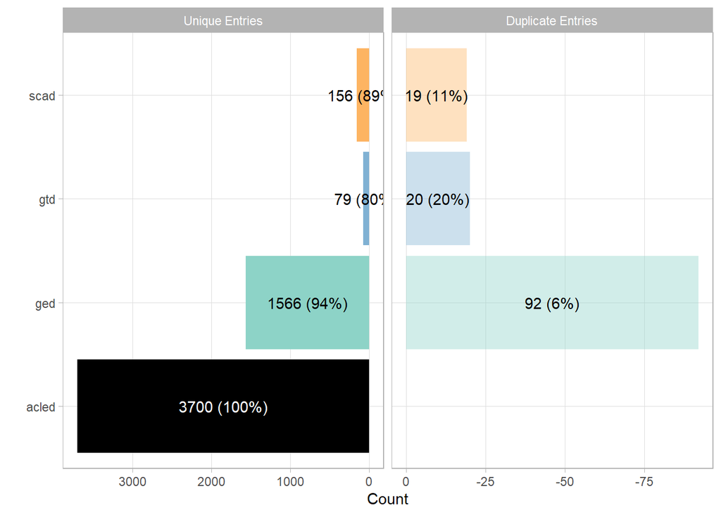

```r
plot(output_km5)
```

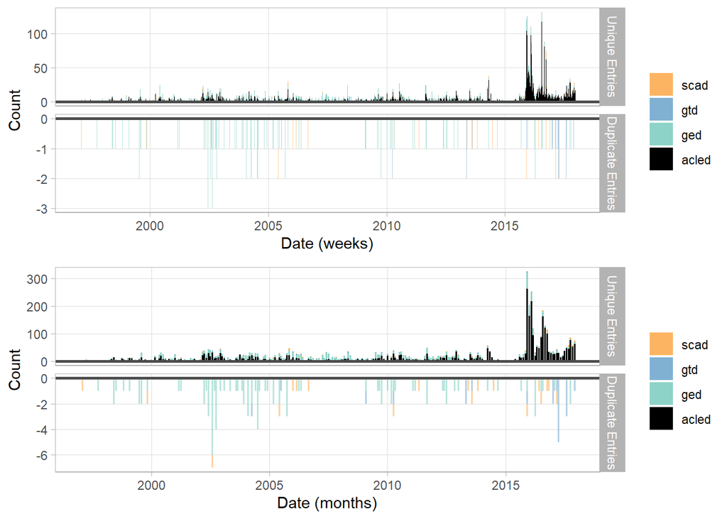

```r
t1 <- meltt::tplot(output_km5, time_unit = "weeks")
t2 <- meltt::tplot(output_km5, time_unit = "months")
gridExtra::grid.arrange(t1,t2)
```

When using a spatio-temporal specification of 1 day, 5 km, the `meltt` package flagged 42 events as potential duplicates (i.e., flagged events). We review all of these and code them manually as either unique or duplicate events.

```r
# Get flagged events and inspect them manually
flagged <- meltt::meltt_inspect(output_km5)
```

```
##
## Note:
## 42 entries flagged as event-to-episode matches. List generated for user evaluation for all potential matches.
```

```r
fl  <- list()
fl2 <- list()

for (i in 1:length(flagged)){
  fl[[i]] <- flagged[[i]]$`Flagged Event Information`$obs.count
  fl2[[i]] <- flagged[[i]]$`Flagged Episode Information`$obs.count
}

#unlist(fl)
#unlist(fl2)

vars_acled <- c(
  "start", "end", "date", "enddate", "event_type", "actor1", "actor2",
  "latitude", "longitude", "actor_tax", "event_tax", "prec_tax")

vars_ged <- c(
  "date", "enddate", "type_of_violence", "dyad_name", "latitude", "longitude",
  "actor_tax", "event_tax", "prec_tax")

vars_scad <- c(
  "startdate", "enddate", "etype", "actor1", "actor2", "latitude", "longitude",
  "actor_tax", "event_tax", "prec_tax", "notes")

#View(acled[unlist(fl[c(1:4,6:30,32:42)]),vars_acled])
#View(ged[unlist(fl2[c(4,6:15,17:25, 28:30, 32:36, 41:42)]),vars_ged])
#View(ged[unlist(fl[c(5)]),vars_ged])
#View(acled[unlist(fl2[c(5, 31)]),vars_acled])
#View(scad[unlist(fl2[c(1:3, 16, 25:27, 37:40)]),vars_scad])
#View(scad[unlist(fl[c(31)]),vars_scad])
```

```r
acled[unlist(fl[1:3]),vars_acled]
```

```
##           start        end       date    enddate      event_type
## 1530 1997-04-12 1997-04-12 1997-04-12 1997-04-12 Remote violence
## 1536 1997-04-12 1997-04-12 1997-04-12 1997-04-12 Remote violence
## 1528 1997-04-14 1997-04-14 1997-04-14 1997-04-14 Remote violence
##                                   actor1                    actor2 latitude
## 1530 Unidentified Armed Group (Ethiopia)      Civilians (Ethiopia)    9.025
## 1536 Unidentified Armed Group (Ethiopia) Civilians (International)    9.025
## 1528 Unidentified Armed Group (Ethiopia)      Civilians (Ethiopia)    9.025
##      longitude                           actor_tax       event_tax prec_tax
## 1530   38.7469 Unidentified Armed Group (Ethiopia) Remote violence        1
## 1536   38.7469 Unidentified Armed Group (Ethiopia) Remote violence        1
## 1528   38.7469 Unidentified Armed Group (Ethiopia) Remote violence        1
```

```r
scad[unlist(fl2[1:3]),vars_scad]
```

```
##     startdate    enddate etype            actor1 actor2 latitude longitude
## 3   12-Apr-97 1997-04-15     9 Unknown attackers         9.02274   38.7468
## 3.1 12-Apr-97 1997-04-15     9 Unknown attackers         9.02274   38.7468
## 3.2 12-Apr-97 1997-04-15     9 Unknown attackers         9.02274   38.7468
##             actor_tax event_tax prec_tax
## 3   Unknown attackers         9        1
## 3.1 Unknown attackers         9        1
## 3.2 Unknown attackers         9        1
##                                                                                                                        notes
## 3   Bombers are almost certainly Al-Itihad, a civil war actor.  However, there is no civil war involving this actor in 1997.
## 3.1 Bombers are almost certainly Al-Itihad, a civil war actor.  However, there is no civil war involving this actor in 1997.
## 3.2 Bombers are almost certainly Al-Itihad, a civil war actor.  However, there is no civil war involving this actor in 1997.
```

```r
# These are the same events, but they affected different targets (civilians from
# Ethiopia and foreigners) on different days. Scad talks of three attacks over
# the span of three days (starting on 12/04/97 until 15/04/97). Because we're
# interested in the number of events (and not length in days), we keep the ACLED
# events --> acled prevails so T for flagged 1:3


# This is the same event but ged spans two days and acled one only. ACLED has
# higher precision
# acled[unlist(fl[4]),vars_acled]
# ged[unlist(fl2[4]),vars_ged]
# --> ged prevails so T for flagged 4 but change start date in acled

# This is the same event. In ged it spans one day (1998-06-02) but in acled 3
# (1998-06-02 to 1998-06-04)
# ged[unlist(fl[5]),vars_ged]
# acled[unlist(fl2[5]),vars_acled]
# --> acled prevails so T for flagged 5 but change end date in ged


# This is the same event but ged spans two days (1998-06-09 to 1998-06-10) and
# acled one only (1998-06-09)
# acled[unlist(fl[6]),vars_acled]
# ged[unlist(fl2[6]),vars_ged]
# --> ged prevails so T for flagged 6 but change start date in acled

# This the not the same event. In acled spans one day (1998-10-07), while 2
# weeks in ged (1998-10-01 to 1998-10-14), plus the actors involved are
# different (civilians vs government)
# acled[unlist(fl[7]),vars_acled]
# ged[unlist(fl2[7]),vars_ged]
# --> F for flagged 7

# This is the same event but ged spans three days (1999-05-24 to 1999-05-26) and
# acled one only
# acled[unlist(fl[8]),vars_acled]
# ged[unlist(fl2[8]),vars_ged]
# --> ged prevails so T for flagged 8 but change end date in acled observation

# This is partially the same event. In ged it spans three days
# (2000-05-23 2000-05-25) and acled one only; but acled has event on 24th (diff
# type of violence) and 25th (same type of violence). Observation fl[10] is NOT
# same event.
# acled[unlist(fl[9:11]),vars_acled]
# ged[unlist(fl2[9:11]),vars_ged]
# if same event
# --> ged prevails so T for flagged 9 and 11, F for flagged 10 but change end
# date in acled observation and remember to drop extra acled observations!


# This is the same event. ACLED talks about “land disputes" resulting in the
# death of 75 people, but only has one day referenced (15/09/2000). GED covers
# all month of September. Difference also in number of deaths (47 in GED).
# acled[unlist(fl[12]),vars_acled]
# ged[unlist(fl2[12]),vars_ged]
# --> ged prevails so T for flagged 12 but but change start and end dates acled


# This is not the same event, different actors are involved (Oromo Liberation
# Front, OLF vs Ogaden National Liberation Front, ONLF)
# acled[unlist(fl[13]),vars_acled]
# ged[unlist(fl2[13]),vars_ged]
# --> F for flagged 13

#This is the same event but in ACLED it was coded as two separate events (on
# 2001-04-17 and 2001-04-18) but the actors involved are the same. ACLED ha a
# further observation on the 19
# acled[unlist(fl[14:15]),vars_acled]
# ged[unlist(fl2[14:15]),vars_ged]
# --> ged prevails so T for flagged 14-15 but change end dates in acled and
# remove extra observations with dates 2001-04-18 and 2001-04-19
```

```r
# This is not the same event, the actors involved are different (opposition
# party members vs protesters and police force)
acled[unlist(fl[16]), vars_acled]
```

```
##           start        end       date    enddate event_type
## 1229 2002-05-24 2002-05-24 2002-05-24 2002-05-24   Protests
##                     actor1                                actor2 latitude
## 1229 Protesters (Ethiopia) Police Forces of Ethiopia (1991-2018)   7.0621
##      longitude             actor_tax event_tax prec_tax
## 1229   38.4764 Protesters (Ethiopia)  Protests        1
```

```r
scad[unlist(fl2[16]), vars_scad]
```

```
##    startdate    enddate etype                   actor1 actor2 latitude
## 24 24-May-02 2002-05-25     1 opposition party members          7.0602
##    longitude                actor_tax event_tax prec_tax notes
## 24   38.4767 opposition party members         1        2
```

```r
# --> F for flagged 16

#This is the same event but in Acled it was coded as two separate events. Acled
# has higher precision
# acled[unlist(fl[17:18]),vars_acled]
# ged[unlist(fl2[17:18]),vars_ged]
# --> acled prevails so T for flagged 17-18, but change end date in acled and
# drop extra observation [18]

# This is the same event but for ged it is 2002-07-18 to 2002-07-19 for acled
# only on 2002-07-18 but then another  event on 2002-07-19
# acled[unlist(fl[19:20]),vars_acled]
# ged[unlist(fl2[19:20]),vars_ged]
# --> ged prevails so T for flagged 19:20 but but change end dates acled and
# remember to drop acled observation for 2002-07-19


# This is the same event but for ged it is from 1-10 for acled on 1 jan (and 8
# jan)
# acled[unlist(fl[21]),vars_acled]
# ged[unlist(fl2[21]),vars_ged]
# --> ged prevails so T for flagged 21 but but change start and end dates acled
# and remember to drop acled observation for 2003-01-08

# This is the same event but for ged it is from 1-10 for acled on 1 jan (and 8
# jan)
# acled[unlist(fl[22]),vars_acled]
# ged[unlist(fl2[22]),vars_ged]
# --> ged prevails so T for flagged 22 but but change start and end dates acled
# and remember to drop acled observation for 2003-01-08


# This is the same event but for ged it is from 1-10 for acled on 1 jan (and 8
# jan)
# acled[unlist(fl[23]),vars_acled]
# ged[unlist(fl2[23]),vars_ged]
# --> ged prevails so T for flagged 23 but but change start and end dates acled
# and remember to drop acled observation for 2003-01-08

#This is the same event but in ged it lasts longer (from 2004-04-01 to
# 2004-04-10)
# acled[unlist(fl[24]),vars_acled]
# ged[unlist(fl2[24]),vars_ged]
# --> ged prevails so T for flagged 24 but but change start and end dates acled


#This is the same event. Coded on slightly different dates (acled and scad).
acled[unlist(fl[25:26]),vars_acled]
```

```
##           start        end       date    enddate event_type
## 1504 2005-11-01 2005-11-01 2005-11-01 2005-11-01   Protests
## 1506 2005-11-02 2005-11-02 2005-11-02 2005-11-02   Protests
##                     actor1                                actor2 latitude
## 1504 Protesters (Ethiopia) Police Forces of Ethiopia (1991-2018)    9.025
## 1506 Protesters (Ethiopia) Police Forces of Ethiopia (1991-2018)    9.025
##      longitude             actor_tax event_tax prec_tax
## 1504   38.7469 Protesters (Ethiopia)  Protests        1
## 1506   38.7469 Protesters (Ethiopia)  Protests        1
```

```r
scad[unlist(fl2[25:26]),vars_scad]
```

```
##      startdate    enddate etype                actor1 actor2 latitude longitude
## 49    1-Nov-05 2005-11-05     2 opposition supporters         9.02274   38.7468
## 49.1  1-Nov-05 2005-11-05     2 opposition supporters         9.02274   38.7468
##                  actor_tax event_tax prec_tax
## 49   opposition supporters         2        4
## 49.1 opposition supporters         2        4
##                                              notes
## 49   protest spread outside the capital on 11-4-05
## 49.1 protest spread outside the capital on 11-4-05
```

```r
# --> acled prevails so T for flagged 26 but but change end dates acled
# ACLED has higher precision, hence it might code other protests (as protests
# break out) as separate geo-coded events. Because we are interested in the
# number of events, not days, we keep ACLED

#This is the same event. Coded on slightly different dates (acled and scad).
acled[unlist(fl[27]),vars_acled]
```

```
##          start        end       date    enddate event_type
## 739 2005-11-03 2005-11-03 2005-11-03 2005-11-03   Protests
##                    actor1 actor2 latitude longitude             actor_tax
## 739 Protesters (Ethiopia)            12.6   37.4667 Protesters (Ethiopia)
##     event_tax prec_tax
## 739  Protests        1
```

```r
scad[unlist(fl2[27]),vars_scad]
```

```
##    startdate    enddate etype                actor1 actor2 latitude longitude
## 44  1-Nov-05 2005-11-05     2 opposition supporters            12.6   37.4667
##                actor_tax event_tax prec_tax
## 44 opposition supporters         2        4
##                                            notes
## 44 protest spread outside the capital on 11-4-05
```

```r
# --> acled prevails so T for flagged 27 but but change end dates acled
# ACLED has higher precision, hence it might code other protests (as protests
# break out) as separate geo-coded events. Because we are interested in the
# number of events, not days, we keep ACLED


#This is the same event but for ged it is from 14-16 nov for acled on 15 nov
# only
# acled[unlist(fl[28]),vars_acled]
# ged[unlist(fl2[28]),vars_ged]
# --> ged prevails so T for flagged 28 but change start and end dates in acled
```

```r
# This is the same event but for ged it is from 9-11 feb for acled on 11 feb
# only
# acled[unlist(fl[29]),vars_acled]
# ged[unlist(fl2[29]),vars_ged]
# --> ged prevails so T for flagged 29 but change start date for acled
# observation

# This the same event. Acled reports only 7/03 while ged 6-7/03
#acled[unlist(fl[30]),vars_acled]
#ged[unlist(fl2[30]),vars_ged]
# --> ged prevails so T for flagged 30 but change start date for acled
# observation

# This is the not the same event. The actors involved and the longitude/latitude
# is different.
scad[unlist(fl[31]),vars_scad]
```

```
##    startdate    enddate etype  actor1 actor2 latitude longitude actor_tax
## 89 15-Jul-12 2012-07-15     2 Muslims         9.02274   38.7468   Muslims
##    event_tax prec_tax notes
## 89         2        1
```

```r
acled[unlist(fl2[31]),vars_acled]
```

```
##           start        end       date    enddate event_type
## 1509 2012-07-13 2012-07-15 2012-07-13 2012-07-15   Protests
##                     actor1                                actor2 latitude
## 1509 Protesters (Ethiopia) Police Forces of Ethiopia (1991-2018)    9.025
##      longitude             actor_tax event_tax prec_tax
## 1509   38.7469 Protesters (Ethiopia)  Protests        1
```

```r
# --> not the same event so F for flagged 31

# This is the not the same event. The actors involved and the longitude/latitude
# is different.
acled[unlist(fl[32]),vars_acled]
```

```
##          start        end       date    enddate                    event_type
## 450 2015-06-01 2015-06-01 2015-06-01 2015-06-01 Battle-No change of territory
##                                      actor1                          actor2
## 450 Military Forces of Ethiopia (1991-2018) Hamar Ethnic Militia (Ethiopia)
##     latitude longitude                               actor_tax
## 450    5.786   36.5652 Military Forces of Ethiopia (1991-2018)
##                         event_tax prec_tax
## 450 Battle-No change of territory        2
```

```r
ged[unlist(fl2[32]),vars_ged]
```

```
##            date    enddate type_of_violence                          dyad_name
## 1250 2015-05-15 2015-05-31                3 Government of Ethiopia - Civilians
##      latitude longitude              actor_tax event_tax prec_tax
## 1250 5.783333  36.56667 Government of Ethiopia         3        3
```

```r
# --> not the same event so F for flagged 32

# This is the same event but for ged it is from 17-20 jan for acled on 18 jan
# only
# acled[unlist(fl[33]),vars_acled]
# ged[unlist(fl2[33]),vars_ged]
# --> ged prevails so T for flagged 33 but change start and end date for acled
# observation

#This is the same event but for ged it is from 12-15 feb for acled on 12 feb
# only
# THOUGH we do have two events on 15 feb one is protests and the other battle
# with armed group. it could be that the protest in acled is type 3 violence in
# ged (so violence against civilians)
# acled[unlist(fl[34]),vars_acled]
# ged[unlist(fl2[34]),vars_ged]
# --> ged prevails so T for flagged 34 but then remember to drop acled
# observation BUT to change enddate for event from 2016-02-15 to 2016-02-14
# because we have the acled observation recorded as protest on 15 feb


# This is the same event but for ged it is from 6-7 aug for acled on 6 aug only
#acled[unlist(fl[35]),vars_acled]
#ged[unlist(fl2[35]),vars_ged]
# --> ged prevails so T for flagged 35 but change end date for acled observation

# This is the same event but for ged it is from 6-7 aug for acled on 6 aug only
#acled[unlist(fl[36]),vars_acled]
#ged[unlist(fl2[36]),vars_ged]
# --> ged prevails so T for flagged 36 but change end date for acled observation

# For scad and acled, we talk about one event that spans 3 days (4-6 oct) in
# scad and 3 days (3-5 oct) in acled, though in acled the 4th of oct is
# categorised as riots and not protest as in scad
#acled[unlist(fl[37:38]),vars_acled]
#scad[unlist(fl2[37:38]),vars_scad]
# --> acled is to keep, as scad notes that "The date of this incident is an
# estimate; no dates were provided by either source, although both indicated the
# attacks spanned multiple days.". Because we are interested in the number of
# events, not days, we give priority to ACLED.
# --> T for flagged 37:38

#This is the same event, but in scad it spans one extra day (4-Oct-16 to
# 2016-10-05)
acled[unlist(fl[39]),vars_acled]
```

```
##           start        end       date    enddate event_type
## 1486 2016-10-05 2016-10-05 2016-10-05 2016-10-05   Protests
##                     actor1 actor2 latitude longitude             actor_tax
## 1486 Protesters (Ethiopia)           9.025   38.7469 Protesters (Ethiopia)
##      event_tax prec_tax
## 1486  Protests        1
```

```r
scad[unlist(fl2[39]),vars_scad]
```

```
##     startdate    enddate etype     actor1 actor2 latitude longitude  actor_tax
## 135  4-Oct-16 2016-10-05     4 Protesters         9.02274   38.7468 Protesters
##     event_tax prec_tax
## 135         4        1
##                                                                                                                                                                                                                                                                                            notes
## 135 The number of stonings, as well as the number of participants in this series of attacks is not mentioned. The time period provided is an estimate; AFP does not specify on which days the stonings occurred, though the rest of the article covers events that transpired on these two days.
```

```r
# --> Acled is to keep, as scad notes "the number of stonings, as well as the
# number of participants in this series of attacks is not mentioned. The time
# period provided is an estimate; AFP does not specify on which days the
# stonings occurred, though the rest of the article covers events that
# transpired on these two days"
# --> T for flagged 39

#This is the same event, but in scad it lasts longer (2017-04-01 to 2017-04-26)
acled[unlist(fl[40]),vars_acled]
```

```
##          start        end       date    enddate      event_type
## 754 2017-04-03 2017-04-03 2017-04-03 2017-04-03 Remote violence
##                                  actor1               actor2 latitude longitude
## 754 Unidentified Armed Group (Ethiopia) Civilians (Ethiopia)     12.6   37.4667
##                               actor_tax       event_tax prec_tax
## 754 Unidentified Armed Group (Ethiopia) Remote violence        1
```

```r
scad[unlist(fl2[40]),vars_scad]
```

```
##     startdate    enddate etype          actor1 actor2 latitude longitude
## 149  1-Apr-17 2017-04-26     9 Unknown Bombers            12.6   37.4667
##           actor_tax event_tax prec_tax
## 149 Unknown Bombers         9        2
##                                                                                                                                   notes
## 149 Dates of this event are estimated.  A source article dated 4/27/17 said that four attacks had taken place ""this month"" in Gondar.
```

```r
# --> Acled is to keep, because it has higher precision and as scad notes "Dates
# of this event are estimated"
# --> T for flagged 40

# This is the same event but in ged it spans more days (2017-10-10 2017-10-12)
acled[unlist(fl[41]),vars_acled]
```

```
##           start        end       date    enddate event_type             actor1
## 2333 2017-10-11 2017-10-11 2017-10-11 2017-10-11      Riots Rioters (Ethiopia)
##                                     actor2 latitude longitude
## 2333 Police Forces of Ethiopia (1991-2018)     8.72     40.64
##               actor_tax event_tax prec_tax
## 2333 Rioters (Ethiopia)     Riots        1
```

```r
ged[unlist(fl2[41]),vars_ged]
```

```
##            date    enddate type_of_violence                          dyad_name
## 1417 2017-10-10 2017-10-12                3 Government of Ethiopia - Civilians
##      latitude longitude              actor_tax event_tax prec_tax
## 1417 8.733333     40.65 Government of Ethiopia         3        1
```

```r
# --> ged prevails so T for flagged 41 but change start and end date for acled
# observation 2017-10-11

# This is the saame event but in ged it spans more days (2017-10-20 to
# 2017-10-22)
acled[unlist(fl[42]),vars_acled]
```

```
##          start        end       date    enddate event_type             actor1
## 317 2017-10-20 2017-10-20 2017-10-20 2017-10-20      Riots Rioters (Ethiopia)
##                 actor2 latitude longitude          actor_tax event_tax prec_tax
## 317 Rioters (Ethiopia)   8.5833   36.1123 Rioters (Ethiopia)     Riots        1
```

```r
ged[unlist(fl2[42]),vars_ged]
```

```
##            date    enddate type_of_violence      dyad_name latitude longitude
## 1581 2017-10-20 2017-10-22                2 Amhara - Oromo 8.605372  36.10482
##      actor_tax event_tax prec_tax
## 1581    Amhara         2        2
```

```r
# --> acled prevails, so T for flagged 42, but change end date in acled
```

We see two examples of flagged events which are indeed duplicates, but were not immediately matched by MELTT because the two original datasets, ACLED and GED, coded the events as happening on slightly different dates:

```r
for (i in c(4, 6)) {
  print(acled[unlist(fl[i]),vars_acled])
  print(ged[unlist(fl2[i]),vars_ged])
  print(paste("This is the same event but in GED it spans two days while in",
        "ACLED only one. We keep the ACLED observation and drop GED, but",
        "because we are interested in the number of events (rather than the",
        "length of events), we then recode the start and/or end date of the",
        "ACLED observation to match GED."))
}
```

```
##           start        end       date    enddate                    event_type
## 2041 1998-05-31 1998-05-31 1998-05-31 1998-05-31 Battle-No change of territory
##                                       actor1                             actor2
## 2041 Military Forces of Ethiopia (1991-2018) Military Forces of Eritrea (1993-)
##      latitude longitude                               actor_tax
## 2041  14.5264   39.5671 Military Forces of Ethiopia (1991-2018)
##                          event_tax prec_tax
## 2041 Battle-No change of territory        1
##           date    enddate type_of_violence
## 696 1998-05-30 1998-05-31                1
##                                          dyad_name latitude longitude
## 696 Government of Eritrea - Government of Ethiopia 14.52728  39.56817
##                  actor_tax event_tax prec_tax
## 696 Government of Ethiopia         1        2
## [1] "This is the same event but in GED it spans two days while in ACLED only one. We keep the ACLED observation and drop GED, but because we are interested in the number of events (rather than the length of events), we then recode the start and/or end date of the ACLED observation to match GED."
##           start        end       date    enddate                    event_type
## 1952 1998-06-09 1998-06-09 1998-06-09 1998-06-09 Battle-No change of territory
##                                       actor1                             actor2
## 1952 Military Forces of Ethiopia (1991-2018) Military Forces of Eritrea (1993-)
##      latitude longitude                               actor_tax
## 1952  14.5219    39.385 Military Forces of Ethiopia (1991-2018)
##                          event_tax prec_tax
## 1952 Battle-No change of territory        1
##           date    enddate type_of_violence
## 699 1998-06-09 1998-06-10                1
##                                          dyad_name latitude longitude
## 699 Government of Eritrea - Government of Ethiopia 14.52194    39.385
##                  actor_tax event_tax prec_tax
## 699 Government of Ethiopia         1        2
## [1] "This is the same event but in GED it spans two days while in ACLED only one. We keep the ACLED observation and drop GED, but because we are interested in the number of events (rather than the length of events), we then recode the start and/or end date of the ACLED observation to match GED."
```

While here we see an examples of a flagged instance where the events, again coming from ACLED and GED, turned out not to be duplicates:

```r
print(acled[unlist(fl[13]),vars_acled])
```

```
##           start        end       date    enddate                    event_type
## 3357 2000-12-09 2000-12-09 2000-12-09 2000-12-09 Battle-No change of territory
##                                       actor1                      actor2
## 3357 Military Forces of Ethiopia (1991-2018) OLF: Oromo Liberation Front
##      latitude longitude                               actor_tax
## 3357   8.2206   43.5572 Military Forces of Ethiopia (1991-2018)
##                          event_tax prec_tax
## 3357 Battle-No change of territory        1
```

```r
print(ged[unlist(fl2[13]),vars_ged])
```

```
##          date    enddate type_of_violence                     dyad_name
## 37 2000-12-06 2000-12-08                1 Government of Ethiopia - ONLF
##    latitude longitude actor_tax event_tax prec_tax
## 37 8.220556  43.55722      ONLF         1        3
```

```r
print(paste("This is not the same event, as the actors involved are different.",
            "ACLED talks of the Military Forces of Ethiopia vs the Oromo",
            "Liberation Front (OLF), while GED talks of the Ethiopian",
            "government against the Ogaden National Liberation Front (ONLF)."))
```

```
## [1] "This is not the same event, as the actors involved are different. ACLED talks of the Military Forces of Ethiopia vs the Oromo Liberation Front (OLF), while GED talks of the Ethiopian government against the Ogaden National Liberation Front (ONLF)."
```

After having assessed which events are unique and which are duplicates, we drop the duplicates to obtain a dataset of uniquely identified events.

```r
# F is to keep both flagged events
# T is to remove episode (not event) from flagged events
# This should mean that the first observation (ACLED in most cases) in the
# flagged dataset is kept
retain <- c(T,T,T,T,T,
            T,F,T,T,F,
            T,T,F,T,T,
            F,T,T,T,T,
            T,T,T,T,T,
            T,T,T,T,T,
            F,F,T,T,T,
            T,T,T,T,T,
            T,T)
merged <- meltt::meltt_inspect(output_km5, confirmed_matches = retain)
```

```
## All confirmed event-to-episode duplicates have been removed.
```

```r
head(merged)
```

```
##   dataset event       date latitude longitude
## 1     ged  1442 1997-01-13 8.250000  34.58333
## 2   acled    78 1997-01-15 8.250000  34.58330
## 3   acled  2906 1997-02-10 9.312200  42.12380
## 4     gtd     1 1997-02-10 9.291957  42.17485
## 5   acled    77 1997-02-15 8.250000  34.58330
## 6     ged  1651 1997-03-01 5.173272  36.54831
##                                         actor_tax
## 1                                           Anuak
## 2 SPLM/A: Sudan People's Liberation Movement/Army
## 3             Unidentified Armed Group (Ethiopia)
## 4                                         Unknown
## 5 SPLM/A: Sudan People's Liberation Movement/Army
## 6                                Hamar (Ethiopia)
##                                  event_tax prec_tax
## 1                                        2        1
## 2 Non-violent activity by a conflict actor        1
## 3                          Remote violence        1
## 4                                        3        1
## 5         Headquarters or base established        1
## 6                                        2        2
```

```r
# Observations acled to drop
acledtodrop <- unlist(fl[c(11, 15, 18, 20)])
merged2 <- merged[!(merged$event %in% acledtodrop & merged$dataset=="acled"),]
#length(merged$event)-length(acledtodrop);length(merged2$event)

# Drop acled x3 and for protesters
a1 <- which(
  acled$latitude==8.2091&acled$longitude==34.1179&acled$date=="2003-01-08")#2681

a2 <- which(
  acled$latitude==8.25&acled$longitude==34.5833&acled$date=="2003-01-08")#2682

a3 <- which(
  acled$latitude==8.2&acled$longitude==34.2667&acled$date=="2003-01-08")#2683

#a4 <- which(
#  acled$latitude == 8.9833 &
#    acled$longitude == 37.85 &
#    acled$date == "2016-08-06" &
#    acled$event_type == "Protests")#351

# a5 <- which(
#   acled$latitude == 7.2 &
#     acled$longitude == 38.6 &
#     acled$date == "2016-08-06" &
#     acled$event_type == "Riots")

#a6 <- which(
#  acled$latitude == 7.1 &
#    acled$longitude == 39.2 &
#    acled$date == "2016-08-06" &
#    acled$event_type=="Riots")

acledtodrop2 <- c(a1,a2,a3)
merged3 <- merged2[
  !(merged2$event %in% acledtodrop2 & merged2$dataset == "acled"),]
```

# 6 Merging into one dataset

After manually reviewing the flagged events, we merge all data to generate the final dataset, which includes 5465 observations.

```r
# changing end and start dates for ACLED

d <- unlist(fl[4])
# This is the same event but ged spans two days and acled one only. ACLED has
# higher precision

cdf$date[cdf$dataset=="acled"&cdf$event==d] <- "1998-05-30"
cdf$enddate[cdf$dataset=="acled"&cdf$event==d] <- "1998-05-31"

d<-unlist(fl[5])
# This is the same event. In ged it spans one day (1998-06-02) but in acled 3
# (1998-06-02 to 1998-06-04)

cdf$enddate[cdf$dataset=="ged" & cdf$event==d] <- "1998-06-04"

d<-unlist(fl[6])
#This is the same event but ged spans two days (1998-06-09 to 1998-06-10) and
# acled one only (1998-06-09)

cdf$enddate[cdf$dataset=="acled"&cdf$event==d] <- "1998-06-10"

d<-unlist(fl[8])
# This is the same event but ged spans three days (1999-05-24 to 1999-05-26)
# and acled one only

cdf$enddate[cdf$dataset=="acled"&cdf$event==d] <- "1999-05-26"

d<-unlist(fl[9])
# This is the same event. In ged it spans three days (2000-05-23 2000-05-25)
# and acled one only; we change end date to match ged

cdf$enddate[cdf$dataset=="acled"&cdf$event==d] <- "2000-05-25"

d<-unlist(fl[12])
# This is the same event. ACLED talks about “land disputes" resulting in the
# death of 75 people, but only has one day referenced (15/09/2000). GED covers
# all month of September. We change daates to match

cdf$date[cdf$dataset=="acled"&cdf$event==d] <- "2000-09-01"
cdf$enddate[cdf$dataset=="acled"&cdf$event==d] <- "2000-09-30"

d<-unlist(fl[14])
#This is the same event but in ACLED it was coded as two separate events (on
# 2001-04-17 and 2001-04-18) but the actors involved are the same. ACLED has a
# further observation on the 19 to be dropped

cdf$date[cdf$dataset=="acled"&cdf$event==d] <- "2001-04-17"
cdf$enddate[cdf$dataset=="acled"&cdf$event==d] <- "2001-04-20"

# adding deaths that wrre recorded for 2001-04-19
cdf$deaths[cdf$dataset=="acled"&cdf$event==d] <- 39

cdf <- cdf[!(cdf$dataset=="acled" & cdf$date=="2001-04-19" & cdf$event ==1545),]

d <- unlist(fl[17])
cdf$enddate[cdf$dataset=="acled"&cdf$event==d] <- "2002-06-23"

d<-unlist(fl[19])
cdf$enddate[cdf$dataset=="acled"&cdf$event==d] <- "2002-07-19"

d<-unlist(fl[21])
cdf$enddate[cdf$dataset=="acled"&cdf$event==d] <- "2003-01-10"

d<-unlist(fl[22])
cdf$enddate[cdf$dataset=="acled"&cdf$event==d] <- "2003-01-10"

d<-unlist(fl[23])
cdf$enddate[cdf$dataset=="acled"&cdf$event==d] <- "2003-01-10"

d<-unlist(fl[24])
cdf$date[cdf$dataset=="acled"&cdf$event==d] <- "2004-04-01"
cdf$enddate[cdf$dataset=="acled"&cdf$event==d] <- "2004-04-10"

d<-unlist(fl[26])
cdf$enddate[cdf$dataset=="acled"&cdf$event==d] <- "2005-11-05"

d<-unlist(fl[27])
cdf$enddate[cdf$dataset=="acled"&cdf$event==d] <- "2005-11-05"

d<-unlist(fl[28])
cdf$date[cdf$dataset=="acled"&cdf$event==d] <- "2005-11-14"
cdf$enddate[cdf$dataset=="acled"&cdf$event==d] <- "2005-11-16"

d<-unlist(fl[29])
cdf$date[cdf$dataset=="acled"&cdf$event==d] <- "2007-02-09"

d<-unlist(fl[30])
cdf$date[cdf$dataset=="acled"&cdf$event==d] <- "2009-03-06"

d<-unlist(fl[33])
cdf$date[cdf$dataset=="acled"&cdf$event==d] <- "2016-01-17"
cdf$enddate[cdf$dataset=="acled"&cdf$event==d] <- "2016-01-20"

d<-unlist(fl[34])
cdf$enddate[cdf$dataset=="acled"&cdf$event==d] <- "2016-02-15"

d<-unlist(fl[35])
cdf$enddate[cdf$dataset=="acled"&cdf$event==d] <- "2016-08-07"

d<-unlist(fl[36])
cdf$enddate[cdf$dataset=="acled"&cdf$event==d] <- "2016-08-07"

d<-unlist(fl[41])
cdf$date[cdf$dataset=="acled"&cdf$event==d] <- "2017-10-10"
cdf$enddate[cdf$dataset=="acled"&cdf$event==d] <- "2017-10-12"

d<-unlist(fl[42])
cdf$enddate[cdf$dataset=="acled"&cdf$event==d] <- "2017-10-22"
```

```
## 'data.frame':    5465 obs. of  12 variables:
##  $ dataset  : chr  "gtd" "ged" "acled" "scad" ...
##  $ date     : Date, format: "1997-02-10" "1999-01-01" ...
##  $ enddate  : Date, format: "1997-02-10" "1999-12-31" ...
##  $ actor_tax: chr  "Unknown" "AIAI" "Majangir Ethnic Militia (Ethiopia)" "students" ...
##  $ actor2   : chr  "" "AIAI" "Amhara Ethnic Militia (Ethiopia)" "" ...
##  $ event_tax: chr  "3" "1" "Battle-No change of territory" "2" ...
##  $ latitude : num  9.29 7 8.02 8.06 8.98 ...
##  $ longitude: num  42.2 44 33.1 39.3 38.8 ...
##  $ event    : int  1 1 1 2 2 2 2 3 3 3 ...
##  $ deaths   : num  2 25 17 0 1 0 4 0 0 7 ...
##  $ notes    : chr  "2/10/1997: A grenade was thrown into the Belayneh Hotel in Harer, Misraq Hararghe zone, Ethiopia. Two people we"| __truncated__ NA NA "" ...
##  $ prec_tax : num  1 4 1 -99 1 3 2 1 1 2 ...
```

To account for potential further duplicates, we look for instances of events where all variables, except the event number, are identical:

```r
duplic <- cdf[
  duplicated(cdf[ , c(
    "dataset", "date", "enddate", "actor_tax", "actor2",
    "event_tax", "latitude", "longitude", "deaths", "notes",
    "prec_tax")]),]

nrow(duplic)
```

```
## [1] 73
```

We also check that the our previous taxonomies (event, precision, and actor) covers all observations in this merged dataset:

```r
cdf_tax <- cdf %>%
  dplyr::left_join(
    event_tax,
    by = c("dataset" = "data.source", "event_tax" = "base.categories")) %>%
  dplyr::left_join(
    prec_tax,
    by = c("dataset" = "data.source", "prec_tax" = "base.categories")) %>%
  dplyr::left_join(
    my_actor_tax,
    by = c("dataset" = "data.source", "actor_tax" = "base.categories"))

apply(cdf_tax, 2, function(x) any(is.na(x)))
```

```
##           dataset              date           enddate         actor_tax
##             FALSE             FALSE             FALSE             FALSE
##            actor2         event_tax          latitude         longitude
##             FALSE             FALSE             FALSE             FALSE
##             event            deaths             notes          prec_tax
##             FALSE              TRUE              TRUE             FALSE
##               X.x      Level_1_text      Level_2_text      Level_3_text
##             FALSE             FALSE             FALSE             FALSE
##      Level_4_text               X.y           Level_1           Level_2
##             FALSE             FALSE             FALSE             FALSE
##           Level_3           Level_4 actor_level_1_txt actor_level_2_txt
##             FALSE             FALSE             FALSE             FALSE
```

# 7 Merging Taxonomy Datasets

```r
# merge event taxonomy dataset
names(event_tax)[2:3] <- c("dataset", "event_tax")
head(cdf[-11])
```

```
##   dataset       date    enddate                          actor_tax
## 1     gtd 1997-02-10 1997-02-10                            Unknown
## 2     ged 1999-01-01 1999-12-31                               AIAI
## 3   acled 2014-07-30 2014-07-30 Majangir Ethnic Militia (Ethiopia)
## 4    scad 1997-03-21 1997-03-21                           students
## 5     gtd 1997-04-12 1997-04-12                            Unknown
## 6     ged 1999-08-08 1999-08-10                               AIAI
##                             actor2                     event_tax latitude
## 1                                                              3 9.291957
## 2                             AIAI                             1 7.000000
## 3 Amhara Ethnic Militia (Ethiopia) Battle-No change of territory 8.024400
## 4                                                              2 8.062010
## 5                                                              3 8.977146
## 6                             AIAI                             1 6.740000
##   longitude event deaths prec_tax
## 1  42.17485     1      2        1
## 2  44.00000     1     25        4
## 3  33.08620     1     17        1
## 4  39.30770     2      0      -99
## 5  38.77323     2      1        1
## 6  44.27806     2      0        3
```

```r
head(event_tax)
```

```
##   X dataset                                  event_tax
## 1 1   acled          Non-violent transfer of territory
## 2 2   acled           Headquarters or base established
## 3 3   acled                                   Protests
## 4 4   acled   Non-violent activity by a conflict actor
## 5 5   acled                                      Riots
## 6 6   acled Battle-Non-state actor overtakes territory
##                    Level_1_text          Level_2_text      Level_3_text
## 1           Territorial Dispute Nonviolent Possession Nonviolent Action
## 2           Territorial Dispute Nonviolent Possession Nonviolent Action
## 3         Protest/Demonstration   Nonviolent Displays Nonviolent Action
## 4         Protest/Demonstration   Nonviolent Displays Nonviolent Action
## 5 Violent Protest/Demonstration      Violent Displays    Violent Action
## 6           Territorial Dispute    Violent Possession    Violent Attack
##       Level_4_text
## 1 Nonviolent Event
## 2 Nonviolent Event
## 3 Nonviolent Event
## 4 Nonviolent Event
## 5    Violent Event
## 6    Violent Event
```

```r
cdf_ev_tax <- merge(cdf, event_tax,
                    by = c("event_tax", "dataset"), all.x = TRUE)

table(cdf_ev_tax$Level_1_text, useNA = "always")
```

```
##
##                      Atrocity                      Coercion
##                           811                            14
##       Opposition-led Violence         Protest/Demonstration
##                           221                          1507
##            State-led Violence             Strategic Assault
##                          1050                            22
##         Strategic Destruction           Territorial Dispute
##                           162                          1433
## Violent Protest/Demonstration        Within-Regime Violence
##                           225                            20
##                          <NA>
##                             0
```

```r
head(cdf_ev_tax)
```

```
##   event_tax dataset       date    enddate           actor_tax actor2 latitude
## 1        -9    scad 1998-01-01 2012-12-31                 OLF        7.546040
## 2        -9    scad 1999-01-01 1999-12-31 al-Itahad al-Islami        8.019040
## 3        -9    scad 2004-01-01 2012-12-31                ONLF        8.019040
## 4        -9    scad 1999-01-01 2002-12-31                ONLF        8.019040
## 5         1     ged 1998-04-05 1998-06-05                ONLF   ONLF 8.220556
## 6         1     ged 2010-01-15 2010-01-15                ONLF   ONLF 8.166667
##   longitude event deaths                 notes prec_tax  X       Level_1_text
## 1  40.63470     4    -77 UPPSALA CONFLICT #219        6 34 State-led Violence
## 2  44.03880     9    -77 UPPSALA CONFLICT #211        6 34 State-led Violence
## 3  44.03880    31    -77 UPPSALA CONFLICT #133        6 34 State-led Violence
## 4  44.03880     8    -77 UPPSALA CONFLICT #133        6 34 State-led Violence
## 5  43.55722     8      1                  <NA>        2 12 State-led Violence
## 6  43.50000   464      0                  <NA>        2 12 State-led Violence
##     Level_2_text   Level_3_text  Level_4_text
## 1 Violent Attack Violent Attack Violent Event
## 2 Violent Attack Violent Attack Violent Event
## 3 Violent Attack Violent Attack Violent Event
## 4 Violent Attack Violent Attack Violent Event
## 5 Violent Attack Violent Attack Violent Event
## 6 Violent Attack Violent Attack Violent Event
```

```r
# merge actor taxonomy dataset
names(actor_tax)[2:3] <- c("dataset", "actor_tax")

head(cdf_ev_tax[-11])
```

```
##   event_tax dataset       date    enddate           actor_tax actor2 latitude
## 1        -9    scad 1998-01-01 2012-12-31                 OLF        7.546040
## 2        -9    scad 1999-01-01 1999-12-31 al-Itahad al-Islami        8.019040
## 3        -9    scad 2004-01-01 2012-12-31                ONLF        8.019040
## 4        -9    scad 1999-01-01 2002-12-31                ONLF        8.019040
## 5         1     ged 1998-04-05 1998-06-05                ONLF   ONLF 8.220556
## 6         1     ged 2010-01-15 2010-01-15                ONLF   ONLF 8.166667
##   longitude event deaths prec_tax  X       Level_1_text   Level_2_text
## 1  40.63470     4    -77        6 34 State-led Violence Violent Attack
## 2  44.03880     9    -77        6 34 State-led Violence Violent Attack
## 3  44.03880    31    -77        6 34 State-led Violence Violent Attack
## 4  44.03880     8    -77        6 34 State-led Violence Violent Attack
## 5  43.55722     8      1        2 12 State-led Violence Violent Attack
## 6  43.50000   464      0        2 12 State-led Violence Violent Attack
##     Level_3_text  Level_4_text
## 1 Violent Attack Violent Event
## 2 Violent Attack Violent Event
## 3 Violent Attack Violent Event
## 4 Violent Attack Violent Event
## 5 Violent Attack Violent Event
## 6 Violent Attack Violent Event
```

```r
head(actor_tax)
```

```
##   X dataset                                                   actor_tax
## 1 1   acled                        Ablek Ad'ali Clan Militia (Ethiopia)
## 2 2   acled                      ADFM: Amhara Democratic Force Movement
## 3 3   acled                              Afar Ethnic Militia (Ethiopia)
## 4 4   acled AGUDM: Patriotic Ginbot 7 for Unity and Democratic Movement
## 5 5   acled                                  AIAI: Al-Itihad Al-Islamia
## 6 6   acled                                     Al-Shabiba Al-Islamiyah
##   actor_level_1_txt actor_level_2_txt
## 1    violent groups    violent groups
## 2   movement groups nonviolent groups
## 3    violent groups    violent groups
## 4   movement groups nonviolent groups
## 5    violent groups    violent groups
## 6    violent groups    violent groups
```

```r
cdf_ac_tax <- merge(cdf_ev_tax, actor_tax,
                 by = c("actor_tax", "dataset"), all.x = TRUE)

table(cdf_ac_tax$actor_level_1_txt, useNA = "always")
```

```
##
##  civilian groups        civilians       government  movement groups
##               16               27             1620             1697
## religious groups   violent groups             <NA>
##                7             1880              218
```

```r
head(cdf_ac_tax)
```

```
##                                actor_tax dataset
## 1   Ablek Ad'ali Clan Militia (Ethiopia)   acled
## 2   Ablek Ad'ali Clan Militia (Ethiopia)   acled
## 3   Ablek Ad'ali Clan Militia (Ethiopia)   acled
## 4   Ablek Ad'ali Clan Militia (Ethiopia)   acled
## 5 ADFM: Amhara Democratic Force Movement   acled
## 6                                   Afar     ged
##                                  event_tax       date    enddate
## 1            Battle-No change of territory 2017-05-04 2017-05-04
## 2            Battle-No change of territory 2017-05-03 2017-05-03
## 3            Battle-No change of territory 2017-05-04 2017-05-04
## 4            Battle-No change of territory 2016-05-01 2016-05-01
## 5 Non-violent activity by a conflict actor 2010-04-15 2010-04-15
## 6                                        2 2012-06-14 2012-06-14
##                                    actor2 latitude longitude event deaths notes
```

[output cut: 20 more lines]

```r
# Create var for actors
# check all actors are categorised
unique(cdf_ac_tax$actor_tax[is.na(cdf_ac_tax$actor_level_1_txt)])
```

```
##  [1] "Amaro Ethnic Militia (Ethiopia)"
##  [2] "APP: Afar People's Party"
##  [3] "Argobba Ethnic Militia (Ethiopia)"
##  [4] "Ari"
##  [5] "Benishangul Gumuz People's Liberation Movement"
##  [6] "Borana, Guji"
##  [7] "Burji Ethnic Militia (Ethiopia)"
##  [8] "Dassanetch"
##  [9] "Degodia"
## [10] "EPRDF: Ethiopian People's Revolutionary Democratic Front"
## [11] "Ethiopian government"
## [12] "Ethnic Oromos"
## [13] "Ethnic Somalis"
## [14] "Gabra"
## [15] "Geri"
```

[output cut: 23 more lines]

```r
# check it again
setdiff(unique(cdf$actor_tax), unique(actor_tax$actor_tax))
```

```
##  [1] "Unknown violent clashes"
##  [2] "Unknown attack"
##  [3] "Benishangul Gumuz People's Liberation Movement"
##  [4] "Security Forces"
##  [5] "Oromo Protesters"
##  [6] "Qeerroo Youth Militia"
##  [7] "TPLF: Tigray People's Liberation Front"
##  [8] "Somali mob"
##  [9] "Oromo rioters"
## [10] "Ethnic Oromos"
## [11] "Somali rioters"
## [12] "Ethnic Somalis"
## [13] "Somali Rioters"
## [14] "Protesters angry over the alleged transportation of sugar to pro-government areas"
## [15] "Ethiopian government"
```

[output cut: 23 more lines]

```r
table(cdf_ac_tax$actor_level_1_txt, useNA = "always")
```

```
##
##  civilian groups        civilians       government  movement groups
##               16               27             1620             1697
## religious groups   violent groups             <NA>
##                7             1880              218
```

```r
cdf_ac_tax$actor_c <- "others"
cdf_ac_tax$actor_c[
  cdf_ac_tax$actor_level_1_txt == "government"] <- "government"
cdf_ac_tax$actor_c[
  cdf_ac_tax$actor_level_1_txt == "violent groups"] <- "violent groups"
cdf_ac_tax$actor_c <- factor(
  cdf_ac_tax$actor_c, levels = c(
    "government","violent groups","others"))
table(cdf_ac_tax$actor_level_1_txt,
      cdf_ac_tax$actor_c, useNA = "always")
```

```
##
##                    government violent groups others <NA>
##   civilian groups           0              0     16    0
##   civilians                 0              0     27    0
##   government             1620              0      0    0
##   movement groups           0              0   1697    0
##   religious groups          0              0      7    0
##   violent groups            0           1880      0    0
##   <NA>                      0              0    218    0
```

```r
# Add rows for month for each event that spanned more than one month
cdf <- data.table::setDT(cdf_ac_tax)[
  , list(dataset = dataset, date = date,
         enddate = enddate, actor_tax = actor_tax,
         actor2 = actor2, event_tax = event_tax,
         latitude = latitude, longitude = longitude,
         event = event, deaths = deaths,
         event_1 = Level_1_text, event_2 = Level_2_text,
         event_3 = Level_3_text, event_4 = Level_4_text,
         actor_1 = actor_level_1_txt, actor_2 = actor_level_2_txt,
         actor_c = actor_c,
         notes = notes, prec_tax = prec_tax,
         month = seq(date, enddate, by = "month")),
  by = 1:nrow(cdf_ac_tax)]

table(cdf$actor_1, cdf$actor_c, useNA = "always")
```

```
##
##                    government violent groups others <NA>
##   civilian groups           0              0     26    0
##   civilians                 0              0     37    0
##   government             1697              0      0    0
##   movement groups           0              0   2035    0
##   religious groups          0              0     18    0
##   violent groups            0           2412      0    0
##   <NA>                      0              0    252    0
```

```r
# Extract month and year from date
cdf$Month_Yr <- zoo::as.yearmon(cdf$month)
```

# 8 Save final dataset

```r
write.csv(cdf4, here::here("data", "ethiopia_conflict.csv"))
saveRDS(cdf4, here::here("data", "ethiopia_conflict.rds"))
haven::write_dta(cdf4, here::here("data", "ethiopia_conflict.dta"))
haven::write_sav(cdf4, here::here("data", "ethiopia_conflict.sav"))
```

# References

Donnay, Karsten, Eric T. Dunford, Erin C. McGrath, David Backer, and David E. Cunningham. 2019. “Integrating Conflict Event Data.” *Journal of Conflict Resolution* 63 (5): 1337–64. https://doi.org/10.1177/0022002718777050.

[^1]: Original author: Micol Morellini.